# Product Segmentation Analysis: KVI/SD/PG Classification

## Assignment Overview

**Objective:** Classify 10,299 retail products into three strategic segments based on limited labeled data (54 samples).

### Business Context

- **KVI (Key Value Items):** Price-competitive essentials that drive store traffic. Customers benchmark prices on these products when choosing retailers.
- **Sales Drivers (SD):** High-volume products with moderate profitability. Used to increase transaction volume and attract customers.
- **Profit Generators (PG):** High-margin items that contribute disproportionately to bottom line despite lower sales volume.

### Challenge

**Semi-supervised learning problem:**

- 10,299 total products
- 54 labeled samples (~0.5%)
- 10,245 unlabeled samples requiring classification

## 1 Libraries and settings

```python
# Core libraries
import pandas as pd
import numpy as np
import matplotlib.pyplot as plt
import seaborn as sns
from pathlib import Path
import warnings
import random

# Seed for reproducibility
SEED = 42
random.seed(SEED)
np.random.seed(SEED)

# Configuration
warnings.filterwarnings('ignore')
sns.set_style('whitegrid')
plt.rcParams['figure.figsize'] = (12, 6)

# Display settings
pd.set_option('display.max_columns', None)
pd.set_option('display.precision', 4)
```

## 2 Data Exploration

### 2.1 Load and Inspect Dataset

```python
# Load data
data_path = Path('/content/drive/MyDrive/Colab Notebooks/Adaptiq/')  # Adjust to your file location
df = pd.read_parquet(data_path / 'data.parquet')

# Initial inspection
print(f"Dataset shape: {df.shape}")
print(f"\nLabeled samples: {df['true_label'].notna().sum()}")
print(f"Unlabeled samples: {df['true_label'].isna().sum()}")
print(f"\nLabel distribution:")
print(df['true_label'].value_counts())
```

```
Dataset shape: (10299, 11)

Labeled samples: 54
Unlabeled samples: 10245

Label distribution:
true_label
PG     28
SD     17
KVI     9
Name: count, dtype: int64
```

```python
# Basic info
df.info()
```

```
<class 'pandas.core.frame.DataFrame'>
RangeIndex: 10299 entries, 0 to 10298
Data columns (total 11 columns):
 #   Column                        Non-Null Count  Dtype
---  ------                        --------------  -----
 0   product_id                    10299 non-null  int64
 1   price_elasticity              10299 non-null  float64
 2   total_online_views            10299 non-null  int64
 3   total_units_sold              10299 non-null  float64
 4   total_revenue                 10299 non-null  float64
 5   median_basket_position        10299 non-null  int64
 6   mean_added_revenue_to_basket  10299 non-null  float64
 7   mean_basket_profit            10299 non-null  float64
 8   competitive_price_range       10299 non-null  float64
 9   price_volatility              10299 non-null  float64
 10  true_label                    54 non-null     object
dtypes: float64(7), int64(3), object(1)
memory usage: 885.2+ KB
```

```python
# Statistical summary
df.describe()
```

|  | product_id | price_elasticity | total_online_views | total_units_sold | total_revenue | median_basket_position | mean_added_revenue_to_basket | mean_basket_profit | competitive_price_range | price_volatility |
| --- | --- | --- | --- | --- | --- | --- | --- | --- | --- | --- |
| count | 10299.0000 | 10299.0000 | 10299.0000 | 10299.0000 | 10299.0000 | 10299.0000 | 10299.0000 | 10299.0000 | 10299.0000 | 10299.0000 |
| mean | 5150.0000 | -0.8974 | 1264.0143 | 233.9070 | 16088.6395 | 3.6066 | 162.3311 | 127.8869 | 6.3942 | 0.0790 |
| std | 2973.2095 | 0.5365 | 870.0514 | 121.1868 | 13689.7875 | 1.4024 | 134.9773 | 90.8981 | 5.8700 | 0.0278 |
| min | 1.0000 | -3.3000 | 21.0000 | -10.5644 | -197.9765 | 1.0000 | 0.2800 | 0.0700 | 0.0400 | 0.0300 |
| 25% | 2575.5000 | -1.2600 | 638.0000 | 134.3230 | 6149.1401 | 2.0000 | 63.5350 | 60.6300 | 2.2600 | 0.0600 |
| 50% | 5150.0000 | -0.8200 | 1049.0000 | 175.0323 | 11743.7691 | 4.0000 | 126.1700 | 107.0400 | 4.4900 | 0.0800 |
| 75% | 7724.5000 | -0.5000 | 1659.5000 | 349.7187 | 21356.1466 | 5.0000 | 223.7600 | 172.8800 | 8.5000 | 0.1000 |
| max | 10299.0000 | 0.8700 | 8827.0000 | 601.7127 | 73600.3232 | 6.0000 | 1128.9200 | 973.1800 | 40.3500 | 0.1800 |

#### 2.1.1 Section summary

**Data quality violations detected across multiple features, compromising model validity and requiring preprocessing decisions.**

Theoretical violations:

- `price_elasticity > 0`: 87 observations (max: 0.87). Violates law of demand. Indicates Giffen goods, data error, or misspecified elasticity calculation.

Logical impossibilities:

- `total_units_sold < 0`: Negative quantities (min: -10.56). Represents returns dominating sales or erroneous aggregation.
- `total_revenue < 0`: Min -197.98. Net-negative transactions shouldn't exist in sales data.

Type inconsistencies:

- `total_units_sold` is float (mean: 233.91). Should be integer. Suggests weighted averaging, prorated periods, or fractional unit handling that wasn't discretized.

Implications for pipeline:

- Feature engineering validity compromised (`revenue_per_unit` division by negative/zero).
- Model will learn spurious patterns from measurement artifacts.
- Semi-supervised propagation will spread label noise if outliers exist in unlabeled set.

Decisions for further analysis:

- Filtering of invalid rows
- Transformation of the total_units_sold to integer dtype
- Outliers detection (both univariate and multivariate)
- Possibility of Z-Score scaling of the features
- Feature engineering on clean and analsyis-ready data, before scaling

### 2.2 Filtering and cleaning the data, feature engineering and outliers detection

**Feature engineering must occur after cleaning but before outlier detection to avoid propagating errors while enabling univariate and multivariate anomaly identification.**

Sequence rationale:

1. **Cleaning first:**
   - Remove structural errors (negative units, impossible values, duplicates).
   - Prevents engineered features from inheriting invalid base values.
   - Example: `revenue_per_unit = total_revenue / total_units_sold` becomes undefined with negative denominators.
2. **Feature engineering second:**
   - Creates derived metrics that expose multivariate relationships.
   - Example: `conversion_rate = total_units_sold / total_online_views` reveals behavioral anomalies invisible in raw features.
   - Interaction terms amplify outlier signatures (e.g., `high elasticity × low revenue` contradicts economics).
3. **Outlier detection last:**
   - Univariate methods on raw features miss relationship-based anomalies.
   - Engineered features make business-logic violations detectable (e.g., `profit_margin_proxy < 0` when both inputs are positive).
   - Isolation Forest/Mahalanobis distance work on full feature space—needs complete set including derived metrics.

Why not reverse order:

- Detecting outliers on raw features alone: Misses products with valid individual values but impossible combinations.
- Engineering after outlier removal: Loses information—some products only become anomalous when interactions are computed.

Pipeline: Clean → Engineer → Detect → Remove/Flag → Model.

```python
# Separate labeled and unlabeled data
df_labeled = df[df['true_label'].notna()].copy()
df_unlabeled = df[df['true_label'].isna()].copy()
```

```python
# Combined violation summary
print("\n=== COMBINED VIOLATION SUMMARY ===\n")

df['has_violation'] = (
    (df['price_elasticity'] > 0) |
    (df['total_units_sold'] < 0) |
    (df['total_revenue'] < 0)
)

print(f"Total rows with violations: {df['has_violation'].sum()} ({df['has_violation'].mean()*100:.2f}%)")

# Check violations in labeled vs unlabeled
labeled_violations = df[df['true_label'].notna()]['has_violation'].sum()
unlabeled_violations = df[df['true_label'].isna()]['has_violation'].sum()

print(f"\nLabeled samples with violations: {labeled_violations}/{df['true_label'].notna().sum()} ({labeled_violations/df['true_label'].notna().sum()*100:.2f}%)")
print(f"Unlabeled samples with violations: {unlabeled_violations}/{df['true_label'].isna().sum()} ({unlabeled_violations/df['true_label'].isna().sum()*100:.2f}%)")
print(f"Remaining total rows: {df['has_violation'].count()- labeled_violations - unlabeled_violations}")

display(df[(df['has_violation']) & (df['true_label'].notna())])
```

```
=== COMBINED VIOLATION SUMMARY ===

Total rows with violations: 256 (2.49%)

Labeled samples with violations: 1/54 (1.85%)
Unlabeled samples with violations: 255/10245 (2.49%)
Remaining total rows: 10043
```

|  | product_id | price_elasticity | total_online_views | total_units_sold | total_revenue | median_basket_position | mean_added_revenue_to_basket | mean_basket_profit | competitive_price_range | price_volatility | true_label | has_violation |
| --- | --- | --- | --- | --- | --- | --- | --- | --- | --- | --- | --- | --- |
| 8244 | 8245 | 0.06 | 195 | 132.7119 | 12327.607 | 5 | 113.02 | 55.37 | 6.77 | 0.09 | PG | True |

```python
# Filtering the violations out of the df and transforming total_units_sold feature to dtype int
df_clean = df[~df['has_violation']].iloc[:,:-1].copy()
df_clean['total_units_sold'] = df_clean['total_units_sold'].astype(int)
display(df_clean.head())
```

|  | product_id | price_elasticity | total_online_views | total_units_sold | total_revenue | median_basket_position | mean_added_revenue_to_basket | mean_basket_profit | competitive_price_range | price_volatility | true_label |
| --- | --- | --- | --- | --- | --- | --- | --- | --- | --- | --- | --- |
| 0 | 1 | -0.56 | 388 | 152 | 9945.5533 | 4 | 64.42 | 185.38 | 4.26 | 0.06 | None |
| 1 | 2 | -1.38 | 2444 | 361 | 49515.4759 | 3 | 504.19 | 46.31 | 25.44 | 0.10 | None |
| 2 | 3 | -0.61 | 1279 | 145 | 3455.4711 | 4 | 46.90 | 248.52 | 1.35 | 0.08 | None |
| 3 | 4 | -0.57 | 813 | 186 | 8312.3234 | 4 | 180.69 | 34.55 | 2.03 | 0.05 | None |
| 4 | 5 | -0.48 | 385 | 146 | 734.4570 | 4 | 36.81 | 227.89 | 0.25 | 0.05 | None |

```python
# Check for duplicate product_ids
print("=== DUPLICATE PRODUCT_ID CHECK ===\n")

duplicates = df_clean[df_clean.duplicated(subset=['product_id'], keep=False)]
n_duplicates = duplicates['product_id'].nunique()
n_duplicate_rows = len(duplicates)

print(f"Duplicate product_ids: {n_duplicates}")
print(f"Total duplicate rows: {n_duplicate_rows}")

if n_duplicate_rows > 0:
    print(f"\nDuplicate product_ids list:")
    duplicate_ids = df_clean[df_clean.duplicated(subset=['product_id'], keep=False)]['product_id'].value_counts()
    print(duplicate_ids)

    print(f"\nSample duplicate rows:")
    print(df_clean[df_clean['product_id'].isin(duplicate_ids.head(3).index)].sort_values('product_id'))

    # Check if duplicates have identical feature values
    print(f"\nChecking if duplicates are exact copies...")
    exact_duplicates = df_clean.duplicated(keep=False).sum()
    print(f"Exact duplicate rows (all features identical): {exact_duplicates}")
else:
    print("No duplicate product_ids found. Dataset integrity confirmed.")
```

```
=== DUPLICATE PRODUCT_ID CHECK ===

Duplicate product_ids: 0
Total duplicate rows: 0
No duplicate product_ids found. Dataset integrity confirmed.
```

#### 2.2.1 Features engineering

**Engineered features target economic relationships, behavioral signals, and competitive positioning that raw metrics don't capture.**

Ratio-based features (margin and efficiency):

- `revenue_per_unit = total_revenue / total_units_sold` — unit price proxy, margin indicator.
- `conversion_rate = total_units_sold / total_online_views` — demand efficiency, purchase intent.
- `basket_value_ratio = mean_added_revenue_to_basket / total_revenue` — basket influence strength relative to total sales.
- `profit_margin_proxy = mean_basket_profit / mean_added_revenue_to_basket` — profitability per basket addition.

Competitive pressure metrics:

- `competitive_pressure = competitive_price_range / revenue_per_unit` — normalized competition intensity (range relative to product's price level).
- `price_stability = 1 / (price_volatility + 0.001)` — inverse volatility, rewards stable pricing.

Behavioral interaction terms:

- `sales_velocity = (total_units_sold / total_online_views) * median_basket_position` — conversion rate weighted by purchase timing.
- `elasticity_revenue_interaction = price_elasticity * total_revenue` — responsiveness scaled by sales magnitude.
- `volatility_competition_interaction = price_volatility * competitive_price_range` — pricing instability under competitive pressure.

Positional features:

- `early_basket_indicator = 1 if median_basket_position <= 2 else 0` — binary flag for impulse/staple items.
- `basket_profit_lift = mean_basket_profit - (total_revenue / total_units_sold)` — incremental basket profitability beyond product's own margin.

Expected segment signatures:

- **KVI**: High `price_elasticity` (negative), high `competitive_pressure`, low `median_basket_position`, low `conversion_rate`.
- **SD**: High `total_units_sold`, high `conversion_rate`, moderate `revenue_per_unit`, low `profit_margin_proxy`.
- **PG**: High `revenue_per_unit`, high `profit_margin_proxy`, low `price_elasticity` (inelastic), low `sales_velocity`, low `competitive_pressure`.

Division safety: Add epsilon (1e-6) to denominators to handle zero/near-zero values.

```python
# Select numeric features (exclude product_id)
numeric_features = df.select_dtypes(include=[np.number]).columns.tolist()
numeric_features.remove('product_id')

print(f"Analyzing {len(numeric_features)} numeric features")
```

```
Analyzing 9 numeric features
```

```python
# Feature engineering on clean data
df_engineered = df_clean.copy()

# Safety epsilon for division
EPSILON = 1e-6
print("=== FEATURE ENGINEERING ===\n")
print("Creating derived features...\n")

# 1. Ratio-based features (margin and efficiency)
print("1. Ratio-based features")

df_engineered['revenue_per_unit'] = (
    df_engineered['total_revenue'] / (df_engineered['total_units_sold'] + EPSILON)
)

df_engineered['conversion_rate'] = (
    df_engineered['total_units_sold'] / (df_engineered['total_online_views'] + EPSILON)
)

df_engineered['basket_value_ratio'] = (
    df_engineered['mean_added_revenue_to_basket'] / (df_engineered['total_revenue'] + EPSILON)
)

df_engineered['profit_margin_proxy'] = (
    df_engineered['mean_basket_profit'] / (df_engineered['mean_added_revenue_to_basket'] + EPSILON)
)

print("  ✓ revenue_per_unit")
print("  ✓ conversion_rate")
print("  ✓ basket_value_ratio")
print("  ✓ profit_margin_proxy")

# 2. Competitive pressure metrics
print("\n2. Competitive pressure metrics")

df_engineered['competitive_pressure'] = (
    df_engineered['competitive_price_range'] / (df_engineered['revenue_per_unit'] + EPSILON)
)

df_engineered['price_stability'] = (
    1 / (df_engineered['price_volatility'] + 0.001)
)

print("  ✓ competitive_pressure")
print("  ✓ price_stability")


# 3. Behavioral interaction terms
print("\n3. Behavioral interaction terms")

df_engineered['sales_velocity'] = (
    (df_engineered['total_units_sold'] / (df_engineered['total_online_views'] + EPSILON)) *
    df_engineered['median_basket_position']
)

df_engineered['elasticity_revenue_interaction'] = (
    df_engineered['price_elasticity'] * df_engineered['total_revenue']
)

df_engineered['volatility_competition_interaction'] = (
    df_engineered['price_volatility'] * df_engineered['competitive_price_range']
)

print("  ✓ sales_velocity")
print("  ✓ elasticity_revenue_interaction")
print("  ✓ volatility_competition_interaction")


# 4. Positional features
print("\n4. Positional features")

df_engineered['early_basket_indicator'] = (
    df_engineered['median_basket_position'] <= 2
).astype(int)

df_engineered['basket_profit_lift'] = (
    df_engineered['mean_basket_profit'] -
    (df_engineered['total_revenue'] / (df_engineered['total_units_sold'] + EPSILON))
)

print("  ✓ early_basket_indicator")
print("  ✓ basket_profit_lift")

# Summary of engineered features
engineered_features = [
    'revenue_per_unit', 'conversion_rate', 'basket_value_ratio', 'profit_margin_proxy',
    'competitive_pressure', 'price_stability', 'sales_velocity',
    'elasticity_revenue_interaction', 'volatility_competition_interaction',
    'early_basket_indicator', 'basket_profit_lift'
]

print(f"\n=== FEATURE ENGINEERING COMPLETE ===")
print(f"Original features: {len(numeric_features)}")
print(f"Engineered features: {len(engineered_features)}")
print(f"Total features: {len(numeric_features) + len(engineered_features)}")
```

```
=== FEATURE ENGINEERING ===

Creating derived features...

1. Ratio-based features
  ✓ revenue_per_unit
  ✓ conversion_rate
  ✓ basket_value_ratio
  ✓ profit_margin_proxy

2. Competitive pressure metrics
  ✓ competitive_pressure
  ✓ price_stability

3. Behavioral interaction terms
  ✓ sales_velocity
  ✓ elasticity_revenue_interaction
  ✓ volatility_competition_interaction

4. Positional features
  ✓ early_basket_indicator
  ✓ basket_profit_lift

=== FEATURE ENGINEERING COMPLETE ===
Original features: 9
Engineered features: 11
Total features: 20
```

```python
# Check for inf/nan in engineered features
print("\n=== ENGINEERED FEATURE QUALITY CHECK ===\n")

for feat in engineered_features:
    n_inf = np.isinf(df_engineered[feat]).sum()
    n_nan = df_engineered[feat].isna().sum()

    if n_inf > 0 or n_nan > 0:
        print(f"{feat}:")
        if n_inf > 0:
            print(f"  Inf values: {n_inf}")
        if n_nan > 0:
            print(f"  NaN values: {n_nan}")

# Handle any remaining inf/nan
df_engineered = df_engineered.replace([np.inf, -np.inf], np.nan)

# Fill remaining NaN with median
for feat in engineered_features:
    if df_engineered[feat].isna().sum() > 0:
        df_engineered[feat].fillna(df_engineered[feat].median(), inplace=True)
        print(f"Imputed {feat} with median")
numeric_features = numeric_features + engineered_features
print("\nAll engineered features validated.")
```

```
=== ENGINEERED FEATURE QUALITY CHECK ===


All engineered features validated.
```

```python
# Display sample of engineered features
print("\n=== SAMPLE ENGINEERED FEATURES ===\n")
sample_cols = ['product_id', 'true_label'] + engineered_features
display(df_engineered[sample_cols].head(10))
```

```
=== SAMPLE ENGINEERED FEATURES ===
```

|  | product_id | true_label | revenue_per_unit | conversion_rate | basket_value_ratio | profit_margin_proxy | competitive_pressure | price_stability | sales_velocity | elasticity_revenue_interaction | volatility_competition_interaction | early_basket_indicator | basket_profit_lift |
| --- | --- | --- | --- | --- | --- | --- | --- | --- | --- | --- | --- | --- | --- |
| 0 | 1 | None | 65.4313 | 0.3918 | 0.0065 | 2.8777 | 0.0651 | 16.3934 | 1.5670 | -5569.5099 | 0.2556 | 0 | 119.9487 |
| 1 | 2 | None | 137.1620 | 0.1477 | 0.0102 | 0.0919 | 0.1855 | 9.9010 | 0.4431 | -68331.3567 | 2.5440 | 0 | -90.8520 |
| 2 | 3 | None | 23.8308 | 0.1134 | 0.0136 | 5.2989 | 0.0566 | 12.3457 | 0.4535 | -2107.8374 | 0.1080 | 0 | 224.6892 |
| 3 | 4 | None | 44.6899 | 0.2288 | 0.0217 | 0.1912 | 0.0454 | 19.6078 | 0.9151 | -4738.0244 | 0.1015 | 0 | -10.1399 |
| 4 | 5 | None | 5.0305 | 0.3792 | 0.0501 | 6.1910 | 0.0497 | 19.6078 | 1.5169 | -352.5394 | 0.0125 | 0 | 222.8595 |
| 5 | 6 | None | 26.7793 | 0.2072 | 0.0060 | 2.3557 | 0.2039 | 9.0090 | 0.6215 | -12313.3741 | 0.6006 | 0 | 121.7007 |
| 6 | 7 | None | 35.6857 | 0.4391 | 0.0348 | 0.0217 | 0.3032 | 6.6225 | 1.7566 | -10366.6908 | 1.6230 | 0 | -26.2457 |
| 7 | 8 | None | 118.7466 | 0.2282 | 0.0013 | 7.5868 | 0.0506 | 16.3934 | 1.1411 | -8425.0740 | 0.3606 | 0 | 70.0134 |
| 8 | 9 | None | 11.0617 | 0.1141 | 0.1774 | 0.3878 | 0.0506 | 19.6078 | 0.6847 | -391.2514 | 0.0280 | 0 | 88.6283 |
| 9 | 10 | None | 120.7257 | 0.3330 | 0.0055 | 0.1467 | 0.1225 | 9.9010 | 0.9990 | -86883.9052 | 1.4790 | 0 | -87.1957 |

#### 2.2.2 Univariate Outliers (IQR Method)

```
Univariate Outliers Summary:
```

|  | feature | n_outliers | pct_outliers | lower_bound | upper_bound |
| --- | --- | --- | --- | --- | --- |
| 12 | profit_margin_proxy | 532 | 5.1656 | -5.9621 | 8.4427 |
| 11 | basket_value_ratio | 463 | 4.4956 | -0.0516 | 0.0776 |
| 17 | volatility_competition_interaction | 212 | 2.0585 | -2.0195 | 2.9101 |
| 15 | sales_velocity | 193 | 1.8740 | -1.8668 | 3.3574 |
| 10 | conversion_rate | 148 | 1.4370 | -0.4431 | 0.8790 |
| 13 | competitive_pressure | 43 | 0.4175 | -0.2044 | 0.3753 |
| 16 | elasticity_revenue_interaction | 37 | 0.3593 | -101609.5151 | 73054.5001 |
| 7 | competitive_price_range | 31 | 0.3010 | -19.9550 | 30.8450 |
| 1 | total_online_views | 26 | 0.2525 | -2946.5000 | 5253.5000 |
| 5 | mean_added_revenue_to_basket | 18 | 0.1748 | -501.8225 | 791.1775 |
| 6 | mean_basket_profit | 11 | 0.1068 | -332.5250 | 565.7150 |
| 19 | basket_profit_lift | 7 | 0.0680 | -441.6973 | 548.0627 |
| 3 | total_revenue | 0 | 0.0000 | -48083.2808 | 75931.7682 |
| 2 | total_units_sold | 0 | 0.0000 | -625.5000 | 1110.5000 |
| 0 | price_elasticity | 0 | 0.0000 | -3.9050 | 2.0950 |
| 4 | median_basket_position | 0 | 0.0000 | -8.5000 | 15.5000 |
| 8 | price_volatility | 0 | 0.0000 | -0.0800 | 0.2400 |
| 9 | revenue_per_unit | 0 | 0.0000 | -180.9032 | 312.7135 |
| 14 | price_stability | 0 | 0.0000 | -12.8226 | 39.1170 |
| 18 | early_basket_indicator | 0 | 0.0000 | -3.5000 | 4.5000 |

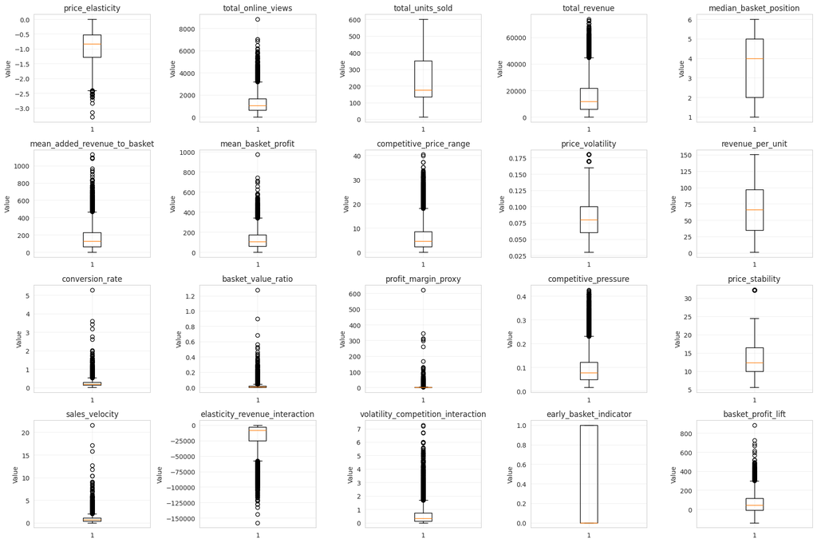

```python
# IQR-based outlier detection
def detect_outliers_iqr(data, feature):
    Q1 = data[feature].quantile(0.25)
    Q3 = data[feature].quantile(0.75)
    IQR = Q3 - Q1
    lower_bound = Q1 - 3.5 * IQR
    upper_bound = Q3 + 3.5 * IQR
    outliers = ((data[feature] < lower_bound) | (data[feature] > upper_bound))
    return outliers, lower_bound, upper_bound

# Detect outliers for each feature
outlier_summary = []
for feature in numeric_features:
    outliers, lower, upper = detect_outliers_iqr(df_engineered, feature)
    n_outliers = outliers.sum()
    pct_outliers = (n_outliers / len(df)) * 100

    outlier_summary.append({
        'feature': feature,
        'n_outliers': n_outliers,
        'pct_outliers': pct_outliers,
        'lower_bound': lower,
        'upper_bound': upper
    })

outlier_df = pd.DataFrame(outlier_summary).sort_values('pct_outliers', ascending=False)
print("\nUnivariate Outliers Summary:")
display(outlier_df)


# Visualize outliers with box plots
fig, axes = plt.subplots(4, 5, figsize=(18, 12))
axes = axes.ravel()

for idx, feature in enumerate(numeric_features):
    if idx < len(axes):
        axes[idx].boxplot(df_engineered[feature].dropna())
        axes[idx].set_title(f'{feature}')
        axes[idx].set_ylabel('Value')
        axes[idx].grid(True, alpha=0.3)

plt.tight_layout()
plt.show()
```

#### 2.2.2 Multivariate Outliers (Isolation Forest)

**Isolation Forest and multivariate outlier detection prevent model degradation by identifying anomalous patterns that univariate methods miss.**

Isolation Forest advantages:

- Detects anomalies in high-dimensional feature space without distance metrics.
- Computationally efficient (O(n log n)) compared to density-based methods.
- No assumption of data distribution (non-parametric).
- Isolates outliers by random partitioning—anomalies require fewer splits to separate.

Multivariate outlier analysis necessity:

- Univariate checks (z-score, IQR per feature) miss interaction effects.
- Point may be normal in each dimension but anomalous in combination (e.g., high elasticity + low revenue contradicts economics).
- Mahalanobis distance captures correlated feature space geometry.

Impact on modeling:

- Prevents outliers from dominating loss function (especially in gradient-based methods).
- Reduces variance in cross-validation performance.
- Improves semi-supervised learning quality—outliers distort similarity graphs in label propagation.
- Enhances interpretability—SHAP values reflect true patterns, not artifacts.

Application to this dataset:

- Identify products with contradictory metrics (positive elasticity + high sales).
- Flag measurement errors vs. genuine edge cases (returns, data collection issues).
- Clean training set before propagating pseudo-labels to 10,245 unlabeled samples.

```python
from sklearn.ensemble import IsolationForest
from sklearn.preprocessing import StandardScaler

# Prepare data for multivariate outlier detection
df_numeric = df_engineered[numeric_features].copy()



# Scale features
scaler = StandardScaler()
df_scaled = scaler.fit_transform(df_numeric)

# Isolation Forest
iso_forest = IsolationForest(
    contamination=0.05,  # Expect 5% outliers
    random_state=SEED,
    n_jobs=-1
)

# Predict outliers (-1 for outliers, 1 for inliers)
outlier_labels = iso_forest.fit_predict(df_scaled)
df_numeric['is_outlier_multivariate'] = (outlier_labels == -1)

print(f"\nMultivariate outliers detected: {df_numeric['is_outlier_multivariate'].sum()} ({df_numeric['is_outlier_multivariate'].mean()*100:.2f}%)")
```

```
Multivariate outliers detected: 503 (5.01%)
```

```python
df_outliers = df_numeric[~df_numeric['is_outlier_multivariate']].iloc[:,:-1].copy()
```

```
Univariate Outliers Summary:
```

|  | feature | n_outliers | pct_outliers | lower_bound | upper_bound |
| --- | --- | --- | --- | --- | --- |
| 12 | profit_margin_proxy | 486 | 4.7189 | -6.0262 | 8.5590 |
| 11 | basket_value_ratio | 404 | 3.9227 | -0.0515 | 0.0776 |
| 15 | sales_velocity | 147 | 1.4273 | -1.8294 | 3.3187 |
| 10 | conversion_rate | 101 | 0.9807 | -0.4277 | 0.8557 |
| 17 | volatility_competition_interaction | 85 | 0.8253 | -1.8083 | 2.6335 |
| 16 | elasticity_revenue_interaction | 61 | 0.5923 | -88524.1745 | 62992.4269 |
| 1 | total_online_views | 22 | 0.2136 | -2902.5000 | 5185.5000 |
| 5 | mean_added_revenue_to_basket | 18 | 0.1748 | -479.5163 | 759.3438 |
| 13 | competitive_pressure | 8 | 0.0777 | -0.1885 | 0.3538 |
| 6 | mean_basket_profit | 7 | 0.0680 | -328.4000 | 561.2800 |
| 3 | total_revenue | 3 | 0.0291 | -43463.8328 | 69824.7293 |
| 19 | basket_profit_lift | 3 | 0.0291 | -434.3968 | 541.1712 |
| 2 | total_units_sold | 0 | 0.0000 | -595.0000 | 1069.0000 |
| 0 | price_elasticity | 0 | 0.0000 | -3.6812 | 1.9387 |
| 4 | median_basket_position | 0 | 0.0000 | -8.5000 | 15.5000 |
| 7 | competitive_price_range | 0 | 0.0000 | -18.3850 | 28.7350 |
| 8 | price_volatility | 0 | 0.0000 | -0.0450 | 0.1950 |
| 9 | revenue_per_unit | 0 | 0.0000 | -179.2707 | 310.6781 |
| 14 | price_stability | 0 | 0.0000 | -7.9265 | 35.3090 |
| 18 | early_basket_indicator | 0 | 0.0000 | -3.5000 | 4.5000 |

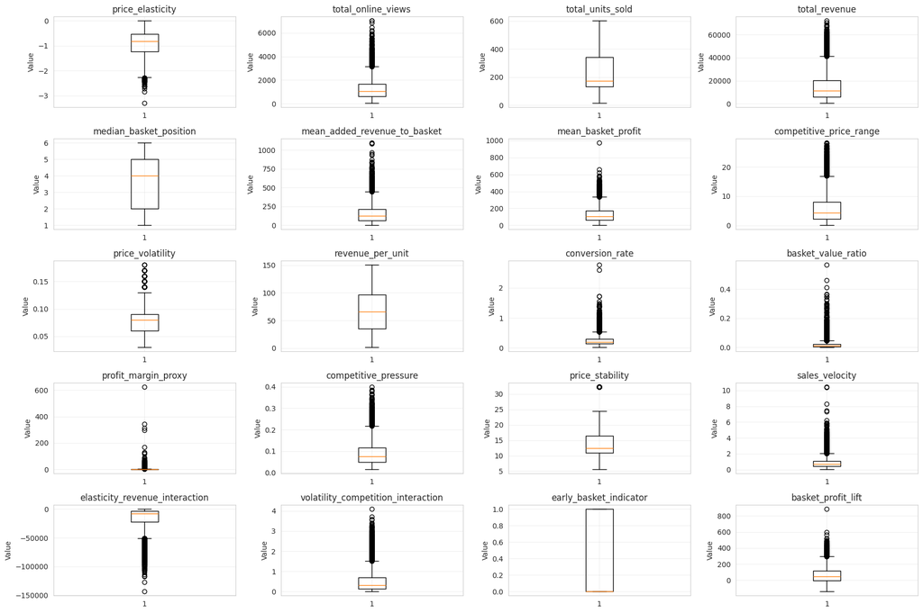

```python
# Re-run the univariate after multivariate adjustments
# IQR-based outlier detection


def detect_outliers_iqr(data, feature):
    Q1 = data[feature].quantile(0.25)
    Q3 = data[feature].quantile(0.75)
    IQR = Q3 - Q1
    lower_bound = Q1 - 3.5 * IQR
    upper_bound = Q3 + 3.5 * IQR
    outliers = ((data[feature] < lower_bound) | (data[feature] > upper_bound))
    return outliers, lower_bound, upper_bound

# Detect outliers for each feature
outlier_summary = []
for feature in numeric_features:
    outliers, lower, upper = detect_outliers_iqr(df_outliers, feature)
    n_outliers = outliers.sum()
    pct_outliers = (n_outliers / len(df)) * 100

    outlier_summary.append({
        'feature': feature,
        'n_outliers': n_outliers,
        'pct_outliers': pct_outliers,
        'lower_bound': lower,
        'upper_bound': upper
    })

outlier_df = pd.DataFrame(outlier_summary).sort_values('pct_outliers', ascending=False)
print("\nUnivariate Outliers Summary:")
display(outlier_df)


# Visualize outliers with box plots
fig, axes = plt.subplots(5, 4, figsize=(18, 12))
axes = axes.ravel()

for idx, feature in enumerate(numeric_features):
    if idx < len(axes):
        axes[idx].boxplot(df_outliers[feature].dropna())
        axes[idx].set_title(f'{feature}')
        axes[idx].set_ylabel('Value')
        axes[idx].grid(True, alpha=0.3)

plt.tight_layout()
plt.show()
```

Distinction:

Univariate outliers:

- Single feature takes extreme value while others remain plausible.
- Example: Product with `profit_margin_proxy = 8.5` (upper outlier) but normal `revenue_per_unit`, `total_units_sold`.
- Interpretation: Genuinely high-margin product—exactly what defines PG segment.
- Business reality: Market naturally contains low-volume/high-margin and high-volume/low-margin products.

Multivariate outliers:

- Feature combination violates economic logic or relationship constraints.
- Example: High `conversion_rate` (0.8) + negative `total_revenue` + high `price_elasticity` (positive).
- Interpretation: Measurement error, data corruption, or edge case (returns, samples, bundles) that doesn't represent product economics.
- No valid business scenario produces this combination.

Univariate outlier retention rationale:

- `profit_margin_proxy` (4.7% outliers): High/low margin products are real segment differentiators, not errors. PG class likely concentrates here.
- `basket_value_ratio` (3.9% outliers): Products with disproportionate basket influence are strategically important—removing them loses KVI/SD signal.
- `sales_velocity` (1.4% outliers): Extremes capture impulse items (high) vs. researched purchases (low)—critical for classification.
- Engineered features may amplify legitimate variance that distinguishes KVI/SD/PG segments.

### 2.3 Features correlation, segment validation and scaling

#### 2.3.1 Correlation Matrix - All Features

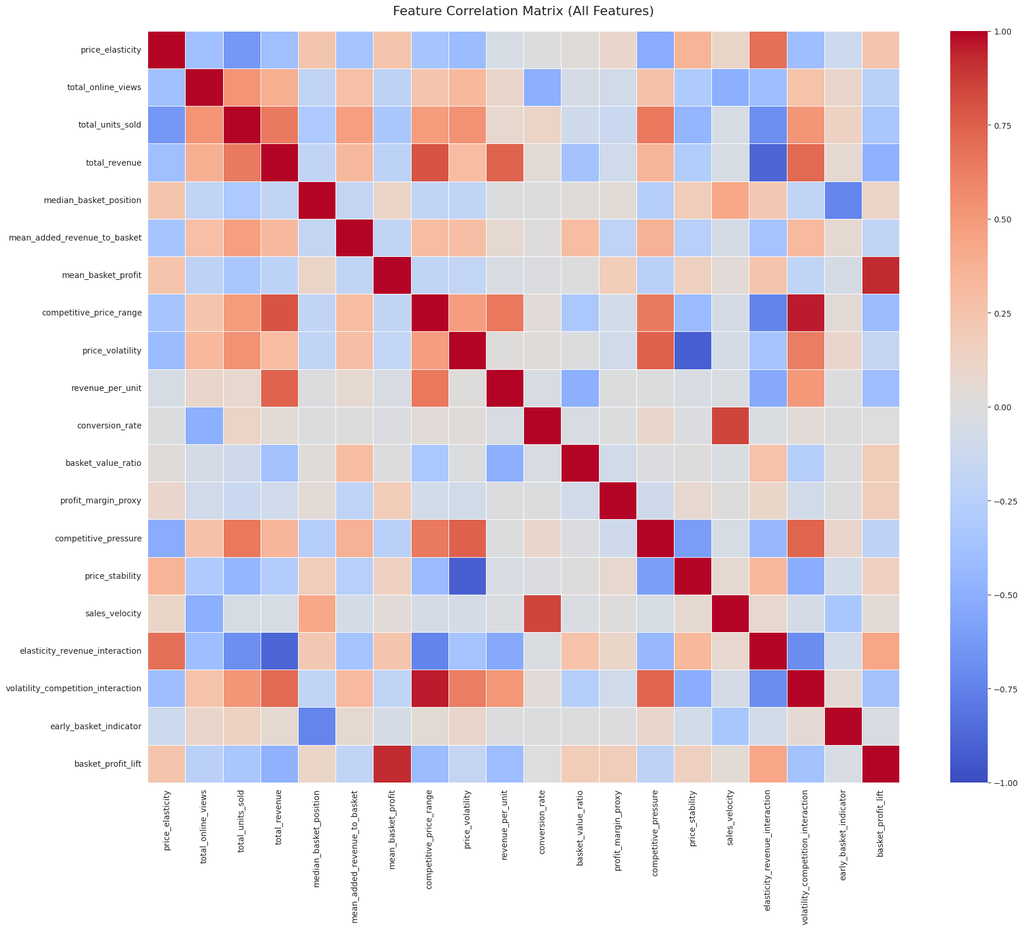

```python
# Compute correlation matrix
correlation_matrix = df_outliers[numeric_features].corr()

# Visualize full correlation matrix
plt.figure(figsize=(20, 16))
sns.heatmap(correlation_matrix,
            annot=False,
            cmap='coolwarm',
            center=0,
            vmin=-1, vmax=1,
            square=True,
            linewidths=0.5)
plt.title('Feature Correlation Matrix (All Features)', fontsize=16, pad=20)
plt.tight_layout()
plt.show()
```

```python
# Identify high correlation pairs (threshold > 0.9)
print("=== HIGH CORRELATION PAIRS (|r| > 0.9) ===\n")

high_corr_pairs = []
for i in range(len(correlation_matrix.columns)):
    for j in range(i+1, len(correlation_matrix.columns)):
        corr_val = correlation_matrix.iloc[i, j]
        if abs(corr_val) > 0.9:
            high_corr_pairs.append({
                'feature_1': correlation_matrix.columns[i],
                'feature_2': correlation_matrix.columns[j],
                'correlation': corr_val
            })

if high_corr_pairs:
    high_corr_df = pd.DataFrame(high_corr_pairs).sort_values('correlation',
                                                               key=abs,
                                                               ascending=False)
    print(high_corr_df.to_string(index=False))
    print(f"\nTotal high correlation pairs: {len(high_corr_pairs)}")
else:
    print("No feature pairs with |correlation| > 0.9 detected.")
```

```
=== HIGH CORRELATION PAIRS (|r| > 0.9) ===

              feature_1                          feature_2  correlation
competitive_price_range volatility_competition_interaction       0.9597
     mean_basket_profit                 basket_profit_lift       0.9253
       price_volatility                    price_stability      -0.9108

Total high correlation pairs: 3
```

```python
# Identify moderate correlation pairs (0.7 < |r| < 0.9) for awareness
print("\n=== MODERATE CORRELATION PAIRS (0.7 < |r| < 0.9) ===\n")

moderate_corr_pairs = []
for i in range(len(correlation_matrix.columns)):
    for j in range(i+1, len(correlation_matrix.columns)):
        corr_val = correlation_matrix.iloc[i, j]
        if 0.7 < abs(corr_val) <= 0.9:
            moderate_corr_pairs.append({
                'feature_1': correlation_matrix.columns[i],
                'feature_2': correlation_matrix.columns[j],
                'correlation': corr_val
            })

if moderate_corr_pairs:
    moderate_corr_df = pd.DataFrame(moderate_corr_pairs).sort_values('correlation',
                                                                       key=abs,
                                                                       ascending=False)
    print(moderate_corr_df.head(10).to_string(index=False))
    print(f"\n... showing top 10 of {len(moderate_corr_pairs)} pairs")
else:
    print("No feature pairs with moderate correlation detected.")
```

```
=== MODERATE CORRELATION PAIRS (0.7 < |r| < 0.9) ===

              feature_1                          feature_2  correlation
          total_revenue     elasticity_revenue_interaction      -0.8827
        conversion_rate                     sales_velocity       0.8453
          total_revenue            competitive_price_range       0.7965
       price_volatility               competitive_pressure       0.7430
          total_revenue                   revenue_per_unit       0.7380
competitive_price_range     elasticity_revenue_interaction      -0.7362
   competitive_pressure volatility_competition_interaction       0.7307
 median_basket_position             early_basket_indicator      -0.7295
          total_revenue volatility_competition_interaction       0.7152

... showing top 10 of 9 pairs
```

**Section summary**

Highly correlated pairs only present with relationship to the derived engineered features, which is expected and logical.

#### 2.3.2 Features scaling

**Scaling before clustering is necessary because distance-based algorithms weight features by their absolute magnitude, not their informative value.**

Without scaling:

- `total_revenue` (range: -197 to 73600) dominates distance calculations over `price_elasticity` (range: -3.3 to 0.87).
- Euclidean distance becomes `sqrt((Δrevenue)^2 + (Δelasticity)^2)` where revenue term is 10,000x larger.
- Clustering groups products by revenue similarity only—ignores elasticity, volatility, competitive pressure entirely.
- K-means centroids drift toward high-variance features, creating revenue-stratified clusters instead of behavior-based segments.

With scaling (RobustScaler):

- All features contribute proportionally to distance metric.
- Products cluster by multivariate similarity across pricing behavior, profitability, demand responsiveness.
- Enables detection of patterns like "low revenue + high margin + low elasticity" = PG candidate.

```python
from sklearn.preprocessing import RobustScaler
df_outliers[['product_id','true_label']] = df_engineered[['product_id','true_label']].copy()
# Separate features and target
X = df_outliers[numeric_features].copy()
```

```python
# Fit RobustScaler on labeled data only (prevent data leakage)
scaler = RobustScaler()
scaler.fit(X)


X_scaled = scaler.transform(X)

print("\n=== SCALING COMPLETE ===\n")
print(f"X_labeled_scaled shape: {X_scaled.shape}")
```

```
=== SCALING COMPLETE ===

X_labeled_scaled shape: (9540, 20)
```

```python
# Convert back to DataFrames for easier handling
X_scaled_df = pd.DataFrame(
    X_scaled,
    columns=numeric_features,
    index = df_outliers.index
)



print("\n=== SCALED DATA SUMMARY ===\n")
print(X_scaled_df.iloc[:5, :5])
print("\nScaled data statistics (should be centered around 0):")
print(X_scaled_df.describe().iloc[:3])
```

```
=== SCALED DATA SUMMARY ===

   price_elasticity  total_online_views  total_units_sold  total_revenue  \
0            0.3559             -0.6449           -0.0913        -0.1103
1           -0.8114              1.3887            0.9135         2.6840
2            0.2847              0.2364           -0.1250        -0.5686
3            0.3416             -0.2245            0.0721        -0.2256
4            0.4698             -0.6479           -0.1202        -0.7607

   median_basket_position
0                  0.0000
1                 -0.3333
2                  0.0000
3                  0.0000
4                  0.0000

Scaled data statistics (should be centered around 0):
       price_elasticity  total_online_views  total_units_sold  total_revenue  \
count         9540.0000           9540.0000         9540.0000      9540.0000
mean            -0.1233              0.2085            0.2733         0.2835
std              0.7093              0.8407            0.5644         0.9231

       median_basket_position  mean_added_revenue_to_basket  \
count               9540.0000                     9540.0000
mean                  -0.1171                        0.2243
std                    0.4602                        0.8432

       mean_basket_profit  competitive_price_range  price_volatility  \
count           9540.0000                9540.0000         9540.0000
mean               0.1778                   0.2696           -0.1001
std                0.7935                   0.8717            0.8301

       revenue_per_unit  conversion_rate  basket_value_ratio  \
count         9540.0000        9540.0000           9540.0000
mean             0.0167           0.2756              0.6055
std              0.5985           1.0447              1.9023

       profit_margin_proxy  competitive_pressure  price_stability  \
count            9540.0000             9540.0000        9540.0000
mean                0.9012                0.2260           0.3957
std                 5.6207                0.8246           1.0585

       sales_velocity  elasticity_revenue_interaction  \
count       9540.0000                       9540.0000
mean           0.3213                         -0.4561
std            1.1329                          1.0487

       volatility_competition_interaction  early_basket_indicator  \
count                           9540.0000               9540.0000
mean                               0.3643                  0.2525
std                                1.0146                  0.4345

       basket_profit_lift
count           9540.0000
mean               0.1278
std                0.7923
```

## 3 Model selection - no prior products distribution

**Objective:** Apply clustering to full unlabeled dataset, validate against labeled samples, generate pseudo-labels with economic rationale.

**Strategy:**

1. Test multiple algorithms (K-Means, Gaussian Mixture, Hierarchical)
2. Tune hyperparameters using silhouette score and Davies-Bouldin index
3. Validate clusters against labeled samples
4. Assign business segment labels based on cluster characteristics
5. Use as pseudo-labels for semi-supervised learning

### 3.1 DT and Clustering Algorithm Selection

```python
from sklearn.cluster import KMeans, AgglomerativeClustering
from sklearn.mixture import GaussianMixture
from sklearn.metrics import silhouette_score, davies_bouldin_score, adjusted_rand_score
from sklearn.metrics import confusion_matrix, classification_report

print("=== DATA SPLIT FOR CLUSTERING ===\n")

# Separate labeled and unlabeled data
mask_labeled = df_outliers['true_label'].notna()

# Training set: unlabeled data only
X_train_cluster = X_scaled_df[~mask_labeled][numeric_features].copy()
train_indices = df_outliers[~mask_labeled].index

# Test set: labeled data
X_test_cluster = X_scaled_df[mask_labeled][numeric_features].copy()
y_test = df_outliers[mask_labeled]['true_label'].copy()
test_indices = df_outliers[mask_labeled].index

print(f"Training set (unlabeled): {X_train_cluster.shape[0]} samples")
print(f"Test set (labeled): {X_test_cluster.shape[0]} samples")
print(f"Features: {X_train_cluster.shape[1]}")
print(f"\nTrue label distribution in test set:")
print(y_test.value_counts())
```

```
=== DATA SPLIT FOR CLUSTERING ===

Training set (unlabeled): 9493 samples
Test set (labeled): 47 samples
Features: 20

True label distribution in test set:
true_label
PG     27
SD     15
KVI     5
Name: count, dtype: int64
```

```python
print("\n=== CLUSTERING ALGORITHM COMPARISON ===\n")
print("Testing: K-Means, Gaussian Mixture Model, Hierarchical Clustering")
print("Training on unlabeled data only\n")

# Storage for results
clustering_results = []
```

```
=== CLUSTERING ALGORITHM COMPARISON ===

Testing: K-Means, Gaussian Mixture Model, Hierarchical Clustering
Training on unlabeled data only
```

#### 3.1.1 Decision Tree estimation on the labeled data

**Rationale**

Even though the labeled data are on a tiny part of the data. Simple decision tree, based on low number of features and with limited depth may produce singificant insight into the groups classification.

**Cons**

The labeled data may not be (and most likely are not) proper representation of the total population, which may provide us with misleading information about the groups classification.

**How to approach**

DT needs to remain simple, with few decision rules. When applied to the unlabeled data, the predicted groups must follow the overall expected economic logic behind the predicted groups.

```
=== DECISION TREE FEATURE SELECTION ===

Training decision tree on labeled samples to identify top discriminative features

Feature Importances (sorted):
                    feature  importance
1        total_online_views      0.4263
13     competitive_pressure      0.2362
6        mean_basket_profit      0.1643
15           sales_velocity      0.1134
10          conversion_rate      0.0598
3             total_revenue      0.0000
0          price_elasticity      0.0000
2          total_units_sold      0.0000
7   competitive_price_range      0.0000
8          price_volatility      0.0000

=== TOP FEATURES FROM DECISION TREE ===
Features used: 5
Top 3-4 features: ['total_online_views', 'competitive_pressure', 'mean_basket_profit', 'sales_velocity']

=== DECISION TREE PERFORMANCE (on labeled data) ===

              precision    recall  f1-score   support

         KVI       0.50      1.00      0.67         5
          PG       1.00      1.00      1.00        27
          SD       1.00      0.67      0.80        15

    accuracy                           0.89        47
   macro avg       0.83      0.89      0.82        47
weighted avg       0.95      0.89      0.90        47


Confusion Matrix:
[[ 5  0  0]
 [ 0 27  0]
 [ 5  0 10]]
```

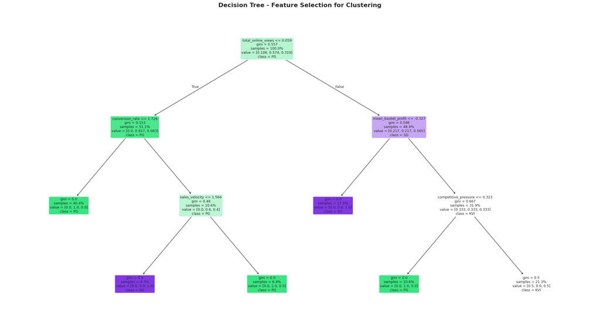

```
================================================================================
DECISION RULES AND THRESHOLD VALUES
================================================================================

Node 0: Split on 'total_online_views' <= 0.0589
  Samples: 47, Impurity: 0.5568
  → LEFT (≤ 0.0589):
  Node 1: Split on 'conversion_rate' <= 1.7291
    Samples: 24, Impurity: 0.1528
    → LEFT (≤ 1.7291):
    LEAF 2: Predict PG
      Class distribution: KVI=0, PG=1, SD=0
      Rule:  AND total_online_views <= 0.0589 AND conversion_rate <= 1.7291

    → RIGHT (> 1.7291):
    Node 3: Split on 'sales_velocity' <= 1.5638
      Samples: 5, Impurity: 0.4800
      → LEFT (≤ 1.5638):
      LEAF 4: Predict SD
        Class distribution: KVI=0, PG=0, SD=1
        Rule:  AND total_online_views <= 0.0589 AND conversion_rate > 1.7291 AND sales_velocity <= 1.5638

      → RIGHT (> 1.5638):
      LEAF 5: Predict PG
        Class distribution: KVI=0, PG=1, SD=0
        Rule:  AND total_online_views <= 0.0589 AND conversion_rate > 1.7291 AND sales_velocity > 1.5638

  → RIGHT (> 0.0589):
  Node 6: Split on 'mean_basket_profit' <= -0.3275
    Samples: 23, Impurity: 0.5860
    → LEFT (≤ -0.3275):
    LEAF 7: Predict SD
      Class distribution: KVI=0, PG=0, SD=1
      Rule:  AND total_online_views > 0.0589 AND mean_basket_profit <= -0.3275

    → RIGHT (> -0.3275):
    Node 8: Split on 'competitive_pressure' <= 0.3232
      Samples: 15, Impurity: 0.6667
      → LEFT (≤ 0.3232):
      LEAF 9: Predict PG
        Class distribution: KVI=0, PG=1, SD=0
        Rule:  AND total_online_views > 0.0589 AND mean_basket_profit > -0.3275 AND competitive_pressure <= 0.3232

      → RIGHT (> 0.3232):
      LEAF 10: Predict KVI
        Class distribution: KVI=0, PG=0, SD=0
        Rule:  AND total_online_views > 0.0589 AND mean_basket_profit > -0.3275 AND competitive_pressure > 0.3232
```

```python
from sklearn.tree import DecisionTreeClassifier, plot_tree

print("=== DECISION TREE FEATURE SELECTION ===\n")
print("Training decision tree on labeled samples to identify top discriminative features\n")

# Train decision tree on labeled data (test set in clustering context)
dt = DecisionTreeClassifier(
    max_depth=3,  # Limit depth for interpretability
    max_features=4,  # Consider top 4 features
    random_state=SEED,
    min_samples_split=5,
    min_samples_leaf=2
)

dt.fit(X_test_cluster, y_test)

# Get feature importance
feature_importances = pd.DataFrame({
    'feature': numeric_features,
    'importance': dt.feature_importances_
}).sort_values('importance', ascending=False)

print("Feature Importances (sorted):")
print(feature_importances.head(10))

# Extract top features (non-zero importance)
top_features_dt = feature_importances[feature_importances['importance'] > 0]['feature'].tolist()
print(f"\n=== TOP FEATURES FROM DECISION TREE ===")
print(f"Features used: {len(top_features_dt)}")
print(f"Top 3-4 features: {top_features_dt[:4]}")

# Classification performance on labeled data
y_pred_dt = dt.predict(X_test_cluster)

print("\n=== DECISION TREE PERFORMANCE (on labeled data) ===\n")
print(classification_report(y_test, y_pred_dt))

print("\nConfusion Matrix:")
cm = confusion_matrix(y_test, y_pred_dt)
print(cm)


# Visualize decision tree
plt.figure(figsize=(22, 12))
plot_tree(
    dt,
    feature_names= numeric_features,
    class_names=['KVI', 'PG', 'SD'],
    filled=True,
    rounded=True,
    fontsize=9,
    proportion=True
)
plt.title("Decision Tree - Feature Selection for Clustering", fontsize=16, fontweight='bold')
plt.tight_layout()
plt.show()


# Extract decision rules
print("\n" + "="*80)
print("DECISION RULES AND THRESHOLD VALUES")
print("="*80 + "\n")

tree = dt.tree_

def get_rules(tree, feature_names, node=0, depth=0, rule=""):
    """Extract decision rules from tree"""
    indent = "  " * depth

    if tree.feature[node] != -2:  # Not a leaf
        name = feature_names[tree.feature[node]]
        thr = tree.threshold[node]

        print(f"{indent}Node {node}: Split on '{name}' <= {thr:.4f}")
        print(f"{indent}  Samples: {tree.n_node_samples[node]}, Impurity: {tree.impurity[node]:.4f}")

        # Left branch
        print(f"{indent}  → LEFT (≤ {thr:.4f}):")
        get_rules(tree, feature_names, tree.children_left[node], depth+1,
                  rule + f" AND {name} <= {thr:.4f}")

        # Right branch
        print(f"{indent}  → RIGHT (> {thr:.4f}):")
        get_rules(tree, feature_names, tree.children_right[node], depth+1,
                  rule + f" AND {name} > {thr:.4f}")
    else:  # Leaf node
        class_counts = tree.value[node][0]
        predicted_class = np.argmax(class_counts)
        class_names = ['KVI', 'PG', 'SD']

        print(f"{indent}LEAF {node}: Predict {class_names[predicted_class]}")
        print(f"{indent}  Class distribution: KVI={int(class_counts[0])}, "
              f"PG={int(class_counts[1])}, SD={int(class_counts[2])}")
        print(f"{indent}  Rule: {rule}\n")

get_rules(tree,  numeric_features)
# Select top 3-4 features for clustering
dt_selected_features = top_features_dt[:4]  # Take top 4
```

```python
# Apply decision tree directly to unlabeled data for prediction
print("\n" + "="*80)
print("DECISION TREE PREDICTIONS ON UNLABELED DATA")
print("="*80 + "\n")

# Predict on unlabeled training data using the trained decision tree
y_pred_unlabeled = dt.predict(X_train_cluster)

# Add predictions to training dataframe
df_train_dt_pred = df_engineered.loc[train_indices].copy()
df_train_dt_pred['predicted_label'] = y_pred_unlabeled

print("Predicted label distribution (unlabeled data):")
print(df_train_dt_pred['predicted_label'].value_counts())
print("\nProportions:")
print(df_train_dt_pred['predicted_label'].value_counts(normalize=True).round(3))
```

```
================================================================================
DECISION TREE PREDICTIONS ON UNLABELED DATA
================================================================================

Predicted label distribution (unlabeled data):
predicted_label
PG     6367
SD     1935
KVI    1191
Name: count, dtype: int64

Proportions:
predicted_label
PG     0.671
SD     0.204
KVI    0.125
Name: proportion, dtype: float64
```

```python
# Describe each predicted segment using NON-SCALED top 4 features
print("\n" + "="*80)
print(f"SEGMENT PROFILES - TOP 4 DT FEATURES (Non-Scaled)")
print(f"Features: {dt_selected_features[:4]}")
print("="*80)

for segment in ['KVI', 'SD', 'PG']:
    segment_data = df_outliers[df_outliers.true_label.isna()][df_train_dt_pred['predicted_label'] == segment]

    print(f"\n{'='*80}")
    print(f"{segment}")
    print(f"{'='*80}")
    print(f"Sample size: {len(segment_data)} ({len(segment_data)/len(df_train_dt_pred)*100:.1f}%)\n")

    # Descriptive statistics for top 4 features (non-scaled)
    stats = segment_data.describe().T
    stats = stats[['mean', 'std', 'min', '25%', '50%', '75%', 'max']]

    print("Descriptive Statistics (Non-Scaled):")
    print(stats.round(4))
```

```
================================================================================
SEGMENT PROFILES - TOP 4 DT FEATURES (Non-Scaled)
Features: ['total_online_views', 'competitive_pressure', 'mean_basket_profit', 'sales_velocity']
================================================================================

================================================================================
KVI
================================================================================
Sample size: 1191 (12.5%)

Descriptive Statistics (Non-Scaled):
                                          mean         std          min  \
price_elasticity                       -1.3040      0.4735      -2.5100
total_online_views                   1962.5659    695.9290    1100.0000
total_units_sold                      353.2729     92.2277      37.0000
total_revenue                       24979.0337  14904.1463     496.9793
median_basket_position                  3.0722      1.0232       1.0000
mean_added_revenue_to_basket          235.1063    142.6267       2.0000
mean_basket_profit                    132.0698     59.3282      70.4800
competitive_price_range                10.8306      5.9379       0.4300
price_volatility                        0.0984      0.0204       0.0600
revenue_per_unit                       71.0274     37.6636       1.5418
conversion_rate                         0.1965      0.0769       0.0223
basket_value_ratio                      0.0172      0.0263       0.0002
profit_margin_proxy                     1.1041      2.8286       0.0881
competitive_pressure                    0.1588      0.0520       0.0969
price_stability                        10.4768      2.1247       5.5249
sales_velocity                          0.5896      0.2839       0.0716
elasticity_revenue_interaction     -33010.8204  22819.3307 -116816.4989
volatility_competition_interaction      1.0867      0.6909       0.0472
early_basket_indicator                  0.3249      0.4685       0.0000
basket_profit_lift                     61.0424     70.1450     -72.5502
product_id                           5125.8950   2961.9281       6.0000

                                           25%         50%         75%  \
price_elasticity                       -1.6500     -1.3200     -1.0050
total_online_views                   1446.5000   1809.0000   2305.0000
total_units_sold                      319.5000    369.0000    410.0000
total_revenue                       12406.3532  23527.7886  35643.6913
median_basket_position                  2.0000      3.0000      4.0000
```

[output cut: 174 more lines]

```
mean_basket_profit                    973.1800
competitive_price_range                26.5600
price_volatility                        0.1800
revenue_per_unit                      150.5039
conversion_rate                         2.7692
basket_value_ratio                      0.5649
profit_margin_proxy                   622.8192
competitive_pressure                    0.3765
price_stability                        32.2581
sales_velocity                         10.4151
elasticity_revenue_interaction          0.0000
volatility_competition_interaction      3.2328
early_basket_indicator                  1.0000
basket_profit_lift                    884.0711
product_id                          10298.0000
```

```
================================================================================
DECISION TREE PREDICTIONS - NON-SCALED DATA WITH QUANTILE LIMITS
================================================================================
```

[figure not shown]

```
================================================================================
MEAN VALUES BY SEGMENT (NON-SCALED DATA)
================================================================================

                          KVI       SD      PG
total_online_views    1962.57  1864.71  931.35
competitive_pressure     0.16     0.12    0.07
mean_basket_profit     132.07    49.23  149.21
sales_velocity           0.59     0.63    1.00
```

```python
# Visualize on original non-scaled data with quantile limits
print("\n" + "="*80)
print("DECISION TREE PREDICTIONS - NON-SCALED DATA WITH QUANTILE LIMITS")
print("="*80 + "\n")

# Add predictions to df_outliers
df_outliers_viz = df_outliers.copy()
df_outliers_viz.loc[~mask_labeled , 'dt_prediction'] = y_pred_unlabeled

# Filter to unlabeled data only
df_unlabeled_viz = df_outliers_viz[~mask_labeled].copy()

fig, axes = plt.subplots(2, 2, figsize=(18, 14))
axes = axes.ravel()

features_viz = ['total_online_views', 'competitive_pressure', 'mean_basket_profit', 'sales_velocity']
colors = {'KVI': 'blue', 'SD': 'green', 'PG': 'red'}

for idx, feature in enumerate(features_viz):
    # Calculate 3rd and 97th percentiles for x-axis limits
    q03 = df_unlabeled_viz[feature].quantile(0.01)
    q97 = df_unlabeled_viz[feature].quantile(0.99)

    # Plot histograms and KDE for each segment
    for segment in ['KVI', 'SD', 'PG']:
        data = df_unlabeled_viz[df_unlabeled_viz['dt_prediction'] == segment][feature]

        if len(data) > 1:
            # Filter data within quantile range for visualization
            data_filtered = data[(data >= q03) & (data <= q97)]

            # Histogram with relative frequency
            axes[idx].hist(data_filtered, alpha=0.3, label=f'{segment} (n={len(data)})',
                          bins=30, color=colors[segment], density=True,
                          edgecolor='black', linewidth=0.5)

            # KDE overlay (on filtered data)
            if len(data_filtered) > 1:
                data_filtered.plot(kind='kde', ax=axes[idx], color=colors[segment],
                                  linewidth=2.5, alpha=0.8)

            # Mean line (full data mean)
            mean_val = data.mean()
            if q03 <= mean_val <= q97:  # Only show if within range
                axes[idx].axvline(mean_val, color=colors[segment], linestyle='--',
                                linewidth=2, alpha=0.9)
                axes[idx].text(mean_val, axes[idx].get_ylim()[1]*0.98,
                              f'{segment}\nμ={mean_val:.2f}',
                              ha='center', fontsize=9, fontweight='bold',
                              bbox=dict(boxstyle='round', facecolor=colors[segment], alpha=0.3))

    # Set x-axis limits to 3rd-97th percentile range
    axes[idx].set_xlim(q03, q97)

    axes[idx].set_title(f'{feature}\n(3rd-97th percentile range)', fontsize=13, fontweight='bold')
    axes[idx].set_xlabel('Original Value', fontsize=11)
    axes[idx].set_ylabel('Density', fontsize=11)
    axes[idx].legend(fontsize=9, loc='best')
    axes[idx].grid(True, alpha=0.3)

plt.tight_layout()
plt.suptitle('Decision Tree Predictions - Original Scale (Unlabeled Data)',
             y=1.00, fontsize=16, fontweight='bold')
plt.show()

# Print mean values table (non-scaled)
print("\n" + "="*80)
print("MEAN VALUES BY SEGMENT (NON-SCALED DATA)")
print("="*80 + "\n")

mean_df_original = pd.DataFrame()
for segment in ['KVI', 'SD', 'PG']:
    segment_data = df_unlabeled_viz[df_unlabeled_viz['dt_prediction'] == segment][features_viz]
    mean_df_original[segment] = segment_data.mean()

print(mean_df_original.round(2))
```

```python
# Detailed statistics
print("\n" + "="*80)
print("DETAILED STATISTICS BY SEGMENT (NON-SCALED DATA)")
print("="*80 + "\n")

for segment in ['KVI', 'SD', 'PG']:
    segment_data = df_unlabeled_viz[df_unlabeled_viz['dt_prediction'] == segment][features_viz]
    print(f"\n{segment} (n={len(segment_data)}):")
    print(segment_data.describe().loc[['mean', 'std', 'min', '25%', '50%', '75%', 'max']].round(2))
```

```
================================================================================
DETAILED STATISTICS BY SEGMENT (NON-SCALED DATA)
================================================================================


KVI (n=1191):
      total_online_views  competitive_pressure  mean_basket_profit  \
mean             1962.57                  0.16              132.07
std               695.93                  0.05               59.33
min              1100.00                  0.10               70.48
25%              1446.50                  0.12               89.16
50%              1809.00                  0.15              115.90
75%              2305.00                  0.19              154.98
max              7019.00                  0.38              623.48

      sales_velocity
mean            0.59
std             0.28
min             0.07
25%             0.38
50%             0.54
75%             0.75
max             1.64

SD (n=1935):
      total_online_views  competitive_pressure  mean_basket_profit  \
mean             1864.71                  0.12               49.23
std               869.51                  0.06               39.15
min               116.00                  0.02                0.07
25%              1322.00                  0.07               29.12
50%              1722.00                  0.12               44.68
75%              2293.00                  0.16               58.78
max              6113.00                  0.40              584.96

      sales_velocity
mean            0.63
std             0.35
min             0.03
25%             0.37
50%             0.55
75%             0.81
max             2.00

PG (n=6367):
      total_online_views  competitive_pressure  mean_basket_profit  \
mean              931.35                  0.07              149.21
std               667.27                  0.04               90.42
min                39.00                  0.02                3.00
25%               528.00                  0.04               84.05
50%               787.00                  0.06              130.34
75%              1086.50                  0.08              197.20
max              7021.00                  0.38              973.18

      sales_velocity
mean            1.00
std             0.83
min             0.03
25%             0.46
50%             0.75
75%             1.25
max            10.42
```

**Decision Tree estimation summary**

#### 3.1.2 Clustering algorithms estimation

Derived from the DT, only the 4 most important features will be used for the clustering algorithm below. Also the clustering algorithm is enforced to keep the economic racionale such as these:

In this part of the modelling, we are not yet enforcing the expected groups distribution accros the data population.

```python
print(f"\n=== CLUSTERING WITH DT-SELECTED FEATURES ===")
print(f"Selected features: {dt_selected_features}\n")

# Prepare data
X_train_dt = X_scaled_df.loc[train_indices, dt_selected_features].values
X_test_dt = X_scaled_df.loc[test_indices, dt_selected_features].values
```

```
=== CLUSTERING WITH DT-SELECTED FEATURES ===
Selected features: ['total_online_views', 'competitive_pressure', 'mean_basket_profit', 'sales_velocity']
```

```python
class MultiFeatureMonotonicKMeans:
    """K-Means with multiple monotonicity constraints"""

    def __init__(self, n_clusters=3, feature_constraints=None, constraint_weights=None,
                 random_state=42, max_iter=300, n_init=20):
        """
        Parameters:
        -----------
        feature_constraints : dict
            {feature_idx: 'ascending' or 'descending'}
            Example: {0: 'descending', 1: 'ascending', 2: 'descending'}
        constraint_weights : dict or None
            {feature_idx: weight} - importance of each constraint
            If None, all features weighted equally
        """
        self.n_clusters = n_clusters
        self.feature_constraints = feature_constraints or {}
        self.constraint_weights = constraint_weights or {k: 1.0 for k in feature_constraints.keys()}
        self.random_state = random_state
        self.max_iter = max_iter
        self.n_init = n_init
        self.kmeans = None
        self.cluster_mapping = None
        self.violation_score = None

    def fit(self, X, feature_names=None):
        """Fit K-Means and find optimal cluster ordering"""
        self.feature_names = feature_names

        # Standard K-Means
        self.kmeans = KMeans(
            n_clusters=self.n_clusters,
            random_state=self.random_state,
            max_iter=self.max_iter,
            n_init=self.n_init
        )
        self.kmeans.fit(X)

        # Find best cluster ordering
        centroids = self.kmeans.cluster_centers_
        self.cluster_mapping, self.violation_score = self._find_best_ordering(centroids)

        return self

    def _find_best_ordering(self, centroids):
        """
        Try all permutations of cluster orderings and find the one
        that best satisfies monotonicity constraints
        """
        from itertools import permutations

        n = self.n_clusters
        all_permutations = list(permutations(range(n)))

        best_mapping = None
        best_score = float('inf')

        for perm in all_permutations:
            # Create mapping: old_id -> new_id
            mapping = {perm[i]: i for i in range(n)}

            # Compute violation score
            score = self._compute_violation_score(centroids, mapping)

            if score < best_score:
                best_score = score
                best_mapping = mapping

        return best_mapping, best_score

    def _compute_violation_score(self, centroids, mapping):
        """
        Compute how much the ordering violates monotonicity constraints
        Lower score = better (0 = perfect monotonicity)
        """
        # Reorder centroids according to mapping
        reordered_centroids = np.zeros_like(centroids)
        for old_id, new_id in mapping.items():
            reordered_centroids[new_id] = centroids[old_id]

        total_violation = 0.0

        for feature_idx, constraint in self.feature_constraints.items():
            weight = self.constraint_weights[feature_idx]
            feature_values = reordered_centroids[:, feature_idx]

            # Check monotonicity violations
            if constraint == 'ascending':
                # Should be: cluster_0 < cluster_1 < cluster_2
                for i in range(self.n_clusters - 1):
                    if feature_values[i] > feature_values[i + 1]:
                        # Violation: should increase but decreases
                        violation = (feature_values[i] - feature_values[i + 1])
                        total_violation += weight * violation

            elif constraint == 'descending':
                # Should be: cluster_0 > cluster_1 > cluster_2
                for i in range(self.n_clusters - 1):
                    if feature_values[i] < feature_values[i + 1]:
                        # Violation: should decrease but increases
                        violation = (feature_values[i + 1] - feature_values[i])
                        total_violation += weight * violation

        return total_violation

    def predict(self, X):
        """Predict cluster labels with monotonic ordering"""
        original_labels = self.kmeans.predict(X)
        remapped_labels = np.array([self.cluster_mapping[label] for label in original_labels])
        return remapped_labels

    @property
    def labels_(self):
        """Get training labels with monotonic ordering"""
        original_labels = self.kmeans.labels_
        return np.array([self.cluster_mapping[label] for label in original_labels])

    def print_cluster_ordering(self, X, original_feature_names):
        """Print resulting cluster means and check monotonicity"""
        remapped_labels = self.labels_

        print("\n" + "="*80)
        print("CLUSTER ORDERING VALIDATION")
        print("="*80 + "\n")

        print("Target constraints:")
        for feat_idx, constraint in self.feature_constraints.items():
            feat_name = original_feature_names[feat_idx]
            print(f"  {feat_name}: {constraint.upper()}")

        print(f"\nCluster mapping (original -> new): {self.cluster_mapping}")
        print(f"Violation score: {self.violation_score:.6f} (0 = perfect)")

        print("\nCluster means (reordered):")
        for cluster_id in range(self.n_clusters):
            cluster_data = X[remapped_labels == cluster_id]
            print(f"\n  Cluster {cluster_id}: {len(cluster_data)} samples")
            for feat_idx in self.feature_constraints.keys():
                feat_name = original_feature_names[feat_idx]
                mean_val = cluster_data[:, feat_idx].mean()
                print(f"    {feat_name}: {mean_val:.4f}")

        # Check if monotonicity is satisfied
        print("\nMonotonicity check:")
        for feat_idx, constraint in self.feature_constraints.items():
            feat_name = original_feature_names[feat_idx]
            values = []
            for cluster_id in range(self.n_clusters):
                cluster_data = X[remapped_labels == cluster_id]
                values.append(cluster_data[:, feat_idx].mean())

            if constraint == 'ascending':
                is_monotonic = all(values[i] <= values[i+1] for i in range(len(values)-1))
                direction = "↑"
            else:
                is_monotonic = all(values[i] >= values[i+1] for i in range(len(values)-1))
                direction = "↓"

            status = "✓" if is_monotonic else "✗"
            print(f"  {status} {feat_name} {direction}: {' → '.join([f'{v:.3f}' for v in values])}")
```

```python
print("\n" + "="*80)
print("MULTI-FEATURE MONOTONIC CLUSTERING")
print("="*80 + "\n")

# Define your target segment ordering based on business logic
print("Target segment characteristics:")
print("  Cluster 0 (KVI): High views, High competition, Med profit, Low velocity")
print("  Cluster 1 (SD):  Med views, Med competition, Low profit, Med velocity")
print("  Cluster 2 (PG):  Low views, Low competition, High profit, High velocity")
print()

# Map to monotonicity constraints (Cluster 0 -> Cluster 1 -> Cluster 2)
# ONLY CONSTRAIN FIRST 2 FEATURES, but use all 4 for clustering
constraints = {
    #'total_online_views': 'descending',      # HIGH -> MED -> LOW (CONSTRAINED)
    'competitive_pressure': 'descending',     # HIGH -> MED -> LOW (CONSTRAINED)
    # mean_basket_profit: NOT CONSTRAINED (but still used in clustering)
    'sales_velocity': 'ascending'             # LOW -> MED -> HIGH
}

# Get feature indices - all 4 features used for clustering
feature_names_list = dt_selected_features[:4]

# Only create constraints for first 2 features
feature_indices = {feature_names_list.index(name): constraint
                   for name, constraint in constraints.items()}

print("Features used for clustering (all 4):")
for feat in feature_names_list:
    print(f"  • {feat}")

print("\nMonotonicity constraints (only first 2):")
for feat_idx, constraint in feature_indices.items():
    print(f"  {feature_names_list[feat_idx]}: {constraint}")

print("\nUnconstrained features (still used for clustering):")
unconstrained = [f for f in feature_names_list if f not in constraints.keys()]
for feat in unconstrained:
    print(f"  • {feat}")
```

```
================================================================================
MULTI-FEATURE MONOTONIC CLUSTERING
================================================================================

Target segment characteristics:
  Cluster 0 (KVI): High views, High competition, Med profit, Low velocity
  Cluster 1 (SD):  Med views, Med competition, Low profit, Med velocity
  Cluster 2 (PG):  Low views, Low competition, High profit, High velocity

Features used for clustering (all 4):
  • total_online_views
  • competitive_pressure
  • mean_basket_profit
  • sales_velocity

Monotonicity constraints (only first 2):
  competitive_pressure: descending
  sales_velocity: ascending

Unconstrained features (still used for clustering):
  • total_online_views
  • mean_basket_profit
```

```python
# Option 1: Equal weights for constrained features
print("\n=== CLUSTERING WITH PARTIAL CONSTRAINTS (Equal Weights) ===\n")

monotonic_model_partial = MultiFeatureMonotonicKMeans(
    n_clusters=3,
    feature_constraints=feature_indices,  # Only 2 features constrained
    constraint_weights=None,  # Equal weights for constrained features
    random_state=SEED
)

# Fit on ALL 4 features (X_train_dt has all 4 features)
monotonic_model_partial.fit(X_train_dt, feature_names=feature_names_list)
monotonic_model_partial.print_cluster_ordering(X_train_dt, feature_names_list)

# Get predictions
labels_train_partial = monotonic_model_partial.labels_
labels_test_partial = monotonic_model_partial.predict(X_test_dt)
```

```
=== CLUSTERING WITH PARTIAL CONSTRAINTS (Equal Weights) ===


================================================================================
CLUSTER ORDERING VALIDATION
================================================================================

Target constraints:
  competitive_pressure: DESCENDING
  sales_velocity: ASCENDING

Cluster mapping (original -> new): {1: 0, 0: 1, 2: 2}
Violation score: 0.214881 (0 = perfect)

Cluster means (reordered):

  Cluster 0: 3014 samples
    competitive_pressure: 0.9982
    sales_velocity: -0.1419

  Cluster 1: 5346 samples
    competitive_pressure: -0.1718
    sales_velocity: 0.0758

  Cluster 2: 1133 samples
    competitive_pressure: 0.0424
    sales_velocity: 2.7045

Monotonicity check:
  ✗ competitive_pressure ↓: 0.998 → -0.172 → 0.042
  ✓ sales_velocity ↑: -0.142 → 0.076 → 2.705
```

```python
# Evaluation after monotonic clustering
print("\n" + "="*80)
print("EVALUATION: MONOTONIC CLUSTERING PERFORMANCE")
print("="*80 + "\n")

# 1. Test set evaluation
df_test_monotonic_eval = pd.DataFrame({
    'true_label': y_test.values,
    'cluster': labels_test_partial
})

# Map clusters to segments using majority voting
cluster_to_segment_eval = {}
for cluster_id in range(3):
    cluster_samples = df_test_monotonic_eval[df_test_monotonic_eval['cluster'] == cluster_id]
    if len(cluster_samples) > 0:
        cluster_to_segment_eval[cluster_id] = cluster_samples['true_label'].mode()[0]
    else:
        cluster_to_segment_eval[cluster_id] = 'UNKNOWN'

print("Cluster-to-Segment Mapping:")
for cluster_id, segment in cluster_to_segment_eval.items():
    count = (df_test_monotonic_eval['cluster'] == cluster_id).sum()
    pct = count / len(df_test_monotonic_eval) * 100
    print(f"  Cluster {cluster_id} → {segment:3s} ({count:2d} samples, {pct:.1f}%)")

df_test_monotonic_eval['predicted'] = df_test_monotonic_eval['cluster'].map(cluster_to_segment_eval)
```

```
================================================================================
EVALUATION: MONOTONIC CLUSTERING PERFORMANCE
================================================================================

Cluster-to-Segment Mapping:
  Cluster 0 → SD  (18 samples, 38.3%)
  Cluster 1 → PG  (21 samples, 44.7%)
  Cluster 2 → PG  ( 8 samples, 17.0%)
```

```python
# 2. Classification metrics
print("\n" + "="*80)
print("CLASSIFICATION METRICS")
print("="*80 + "\n")

from sklearn.metrics import accuracy_score, precision_score, recall_score, f1_score

test_accuracy = accuracy_score(df_test_monotonic_eval['true_label'],
                                df_test_monotonic_eval['predicted'])
test_precision = precision_score(df_test_monotonic_eval['true_label'],
                                  df_test_monotonic_eval['predicted'],
                                  average='macro')
test_recall = recall_score(df_test_monotonic_eval['true_label'],
                            df_test_monotonic_eval['predicted'],
                            average='macro')
test_f1 = f1_score(df_test_monotonic_eval['true_label'],
                   df_test_monotonic_eval['predicted'],
                   average='macro')
test_ari = adjusted_rand_score(df_test_monotonic_eval['true_label'],
                                df_test_monotonic_eval['cluster'])

print("Overall Metrics:")
print(f"  Accuracy:  {test_accuracy:.4f}")
print(f"  Precision: {test_precision:.4f} (macro avg)")
print(f"  Recall:    {test_recall:.4f} (macro avg)")
print(f"  F1-Score:  {test_f1:.4f} (macro avg)")
print(f"  ARI:       {test_ari:.4f}")

print("\nClustering Quality Metrics:")
silhouette_test = silhouette_score(X_test_dt, labels_test_partial)
davies_bouldin_test = davies_bouldin_score(X_test_dt, labels_test_partial)
print(f"  Silhouette Score:     {silhouette_test:.4f} (higher is better)")
print(f"  Davies-Bouldin Index: {davies_bouldin_test:.4f} (lower is better)")
```

```
================================================================================
CLASSIFICATION METRICS
================================================================================

Overall Metrics:
  Accuracy:  0.8085
  Precision: 0.5211 (macro avg)
  Recall:    0.5877 (macro avg)
  F1-Score:  0.5519 (macro avg)
  ARI:       0.3864

Clustering Quality Metrics:
  Silhouette Score:     0.2808 (higher is better)
  Davies-Bouldin Index: 1.1011 (lower is better)
```

```python
# 7. Training set pseudo-label distribution with corrected mapping
print("\n" + "="*80)
print("TRAINING SET PSEUDO-LABEL DISTRIBUTION")
print("="*80 + "\n")

df_train_monotonic_eval = df_engineered.loc[train_indices].copy()
df_train_monotonic_eval['cluster'] = labels_train_partial

# Analyze cluster characteristics to assign correct labels
print("Analyzing cluster characteristics for correct segment assignment...\n")

cluster_characteristics = df_train_monotonic_eval.groupby('cluster')[
    ['total_online_views', 'competitive_pressure', 'mean_basket_profit', 'sales_velocity']
].mean()

print("Cluster means (non-scaled features):")
print(cluster_characteristics.round(4))
print()

# Assign segments based on competitive_pressure ordering
# KVI: HIGHEST competitive_pressure
# SD:  MEDIUM competitive_pressure
# PG:  LOWEST competitive_pressure

# Sort clusters by competitive_pressure (descending)
cluster_pressure_ranked = cluster_characteristics['competitive_pressure'].sort_values(ascending=False)

print("Clusters ranked by competitive_pressure (HIGH → LOW):")
for rank, (cluster_id, pressure) in enumerate(cluster_pressure_ranked.items()):
    print(f"  Rank {rank}: Cluster {cluster_id} → pressure = {pressure:.4f}")
print()

# Create corrected mapping based on competitive_pressure
corrected_cluster_to_segment = {
    cluster_pressure_ranked.index[0]: 'KVI',  # Highest pressure
    cluster_pressure_ranked.index[1]: 'SD',   # Medium pressure
    cluster_pressure_ranked.index[2]: 'PG'    # Lowest pressure
}

print("Corrected Cluster-to-Segment Mapping (based on competitive_pressure):")
for cluster_id in range(3):
    segment = corrected_cluster_to_segment[cluster_id]
    pressure = cluster_characteristics.loc[cluster_id, 'competitive_pressure']
    count = (df_train_monotonic_eval['cluster'] == cluster_id).sum()
    print(f"  Cluster {cluster_id} → {segment} (pressure={pressure:.4f}, n={count})")
print()

# Apply corrected mapping
df_train_monotonic_eval['pseudo_label'] = df_train_monotonic_eval['cluster'].map(corrected_cluster_to_segment)

print("Pseudo-label distribution (unlabeled training data):")
print(df_train_monotonic_eval['pseudo_label'].value_counts().sort_index())
print("\nProportions:")
print(df_train_monotonic_eval['pseudo_label'].value_counts(normalize=True).sort_index().round(4))

# Verify segment characteristics match expectations
print("\n" + "="*80)
print("SEGMENT CHARACTERISTICS VERIFICATION")
print("="*80 + "\n")

segment_profiles = df_train_monotonic_eval.groupby('pseudo_label')[
    ['total_online_views', 'competitive_pressure', 'mean_basket_profit', 'sales_velocity']
].mean()

print("Segment profiles (mean values):")
print(segment_profiles.round(4))
print()

print("Expected vs Actual:")
print("  KVI: Expected HIGH competitive_pressure")
print(f"       Actual: {segment_profiles.loc['KVI', 'competitive_pressure']:.4f}")
print("  SD:  Expected MEDIUM competitive_pressure")
print(f"       Actual: {segment_profiles.loc['SD', 'competitive_pressure']:.4f}")
print("  PG:  Expected LOW competitive_pressure")
print(f"       Actual: {segment_profiles.loc['PG', 'competitive_pressure']:.4f}")
print()

# Check if ordering is correct
kvi_pressure = segment_profiles.loc['KVI', 'competitive_pressure']
sd_pressure = segment_profiles.loc['SD', 'competitive_pressure']
pg_pressure = segment_profiles.loc['PG', 'competitive_pressure']

is_correct_order = (kvi_pressure > sd_pressure) and (sd_pressure > pg_pressure)
status = "✓ CORRECT" if is_correct_order else "✗ INCORRECT"

print(f"{status} ordering: KVI ({kvi_pressure:.4f}) > SD ({sd_pressure:.4f}) > PG ({pg_pressure:.4f})")
```

```
================================================================================
TRAINING SET PSEUDO-LABEL DISTRIBUTION
================================================================================

Analyzing cluster characteristics for correct segment assignment...

Cluster means (non-scaled features):
         total_online_views  competitive_pressure  mean_basket_profit  \
cluster
0                 2107.1400                0.1426             78.9713
1                  943.9478                0.0633            152.4575
2                  422.1536                0.0778            131.9622

         sales_velocity
cluster
0                0.5736
1                0.7137
2                2.4054

Clusters ranked by competitive_pressure (HIGH → LOW):
  Rank 0: Cluster 0 → pressure = 0.1426
  Rank 1: Cluster 2 → pressure = 0.0778
  Rank 2: Cluster 1 → pressure = 0.0633

Corrected Cluster-to-Segment Mapping (based on competitive_pressure):
  Cluster 0 → KVI (pressure=0.1426, n=3014)
  Cluster 1 → PG (pressure=0.0633, n=5346)
  Cluster 2 → SD (pressure=0.0778, n=1133)

Pseudo-label distribution (unlabeled training data):
pseudo_label
KVI    3014
PG     5346
SD     1133
Name: count, dtype: int64

Proportions:
pseudo_label
KVI    0.3175
PG     0.5632
```

[output cut: 14 more lines]

```
              sales_velocity
pseudo_label
KVI                   0.5736
PG                    0.7137
SD                    2.4054

Expected vs Actual:
  KVI: Expected HIGH competitive_pressure
       Actual: 0.1426
  SD:  Expected MEDIUM competitive_pressure
       Actual: 0.0778
  PG:  Expected LOW competitive_pressure
       Actual: 0.0633

✓ CORRECT ordering: KVI (0.1426) > SD (0.0778) > PG (0.0633)
```

```python
# Update cluster_to_segment_eval for consistency in remaining evaluation
cluster_to_segment_eval = corrected_cluster_to_segment.copy()

print("\n" + "="*80)
print("UPDATED SEGMENT ASSIGNMENT")
print("="*80 + "\n")
print("All subsequent evaluations will use the corrected mapping:")
for cluster_id, segment in cluster_to_segment_eval.items():
    print(f"  Cluster {cluster_id} → {segment}")
```

```
================================================================================
UPDATED SEGMENT ASSIGNMENT
================================================================================

All subsequent evaluations will use the corrected mapping:
  Cluster 0 → KVI
  Cluster 2 → SD
  Cluster 1 → PG
```

```python
# Re-evaluate test set with corrected mapping
print("\n" + "="*80)
print("TEST SET RE-EVALUATION (Corrected Mapping)")
print("="*80 + "\n")

df_test_monotonic_eval['predicted'] = df_test_monotonic_eval['cluster'].map(corrected_cluster_to_segment)

# Updated metrics
test_accuracy_corrected = accuracy_score(df_test_monotonic_eval['true_label'],
                                         df_test_monotonic_eval['predicted'])
test_f1_corrected = f1_score(df_test_monotonic_eval['true_label'],
                             df_test_monotonic_eval['predicted'],
                             average='macro')
test_ari_corrected = adjusted_rand_score(df_test_monotonic_eval['true_label'],
                                         df_test_monotonic_eval['cluster'])

print("Updated Test Metrics:")
print(f"  Accuracy:  {test_accuracy_corrected:.4f}")
print(f"  F1-Score:  {test_f1_corrected:.4f} (macro avg)")
print(f"  ARI:       {test_ari_corrected:.4f}")

print("\nUpdated Classification Report:")
print(classification_report(df_test_monotonic_eval['true_label'],
                           df_test_monotonic_eval['predicted']))

print("\nUpdated Confusion Matrix:")
cm_corrected = confusion_matrix(df_test_monotonic_eval['true_label'],
                               df_test_monotonic_eval['predicted'],
                               labels=['KVI', 'SD', 'PG'])
cm_corrected_df = pd.DataFrame(cm_corrected,
                               index=['True KVI', 'True SD', 'True PG'],
                               columns=['Pred KVI', 'Pred SD', 'Pred PG'])
print(cm_corrected_df)
```

```
================================================================================
TEST SET RE-EVALUATION (Corrected Mapping)
================================================================================

Updated Test Metrics:
  Accuracy:  0.5319
  F1-Score:  0.4378 (macro avg)
  ARI:       0.3864

Updated Classification Report:
              precision    recall  f1-score   support

         KVI       0.28      1.00      0.43         5
          PG       0.90      0.70      0.79        27
          SD       0.12      0.07      0.09        15

    accuracy                           0.53        47
   macro avg       0.44      0.59      0.44        47
weighted avg       0.59      0.53      0.53        47


Updated Confusion Matrix:
          Pred KVI  Pred SD  Pred PG
True KVI         5        0        0
True SD         12        1        2
True PG          1        7       19
```

```
================================================================================
CORRECTED SEGMENT PROFILES - ALL 4 FEATURES (KDE + MEANS + QUANTILE LIMITS)
================================================================================
```

[figure not shown]

```
================================================================================
MEAN VALUES BY SEGMENT (CLUSTERING)
================================================================================

                          KVI      SD      PG
total_online_views    2107.14  422.15  943.95
competitive_pressure     0.14    0.08    0.06
mean_basket_profit      78.97  131.96  152.46
sales_velocity           0.57    2.41    0.71
```

```python
# Visualize corrected segment profiles with KDE, means, and quantile limits
print("\n" + "="*80)
print("CORRECTED SEGMENT PROFILES - ALL 4 FEATURES (KDE + MEANS + QUANTILE LIMITS)")
print("="*80 + "\n")

fig, axes = plt.subplots(2, 2, figsize=(18, 14))
axes = axes.ravel()

features_viz = ['total_online_views', 'competitive_pressure', 'mean_basket_profit', 'sales_velocity']
colors = {'KVI': 'blue', 'SD': 'green', 'PG': 'red'}

for idx, feature in enumerate(features_viz):
    # Calculate 3rd and 97th percentiles for x-axis limits
    q03 = df_train_monotonic_eval[feature].quantile(0.01)
    q97 = df_train_monotonic_eval[feature].quantile(0.99)

    # Plot histograms and KDE for each segment
    for segment in ['KVI', 'SD', 'PG']:
        data = df_train_monotonic_eval[df_train_monotonic_eval['pseudo_label'] == segment][feature]

        if len(data) > 1:
            # Filter data within quantile range for visualization
            data_filtered = data[(data >= q03) & (data <= q97)]

            # Histogram with relative frequency
            axes[idx].hist(data_filtered, alpha=0.3, label=f'{segment} (n={len(data)})',
                          bins=30, color=colors[segment], density=True,
                          edgecolor='black', linewidth=0.5)

            # KDE overlay (on filtered data)
            if len(data_filtered) > 1:
                data_filtered.plot(kind='kde', ax=axes[idx], color=colors[segment],
                                  linewidth=2.5, alpha=0.8)

            # Mean line (full data mean)
            mean_val = data.mean()
            if q03 <= mean_val <= q97:  # Only show if within range
                axes[idx].axvline(mean_val, color=colors[segment], linestyle='--',
                                linewidth=2, alpha=0.9)
                axes[idx].text(mean_val, axes[idx].get_ylim()[1]*0.99,
                              f'{segment}\nμ={mean_val:.2f}',
                              ha='center', fontsize=9, fontweight='bold',
                              bbox=dict(boxstyle='round', facecolor=colors[segment], alpha=0.3))

    # Set x-axis limits to 3rd-97th percentile range
    axes[idx].set_xlim(q03, q97)

    axes[idx].set_title(f'{feature}\n(3rd-97th percentile range)', fontsize=13, fontweight='bold')
    axes[idx].set_xlabel('Original Value', fontsize=11)
    axes[idx].set_ylabel('Density', fontsize=11)
    axes[idx].legend(fontsize=9, loc='best')
    axes[idx].grid(True, alpha=0.3)

plt.tight_layout()
plt.suptitle('Corrected Segment Profiles - Original Scale with KDE',
             y=1.00, fontsize=16, fontweight='bold')
plt.show()

# Print mean values table
print("\n" + "="*80)
print("MEAN VALUES BY SEGMENT (CLUSTERING)")
print("="*80 + "\n")

mean_df_clustering = pd.DataFrame()
for segment in ['KVI', 'SD', 'PG']:
    segment_data = df_train_monotonic_eval[df_train_monotonic_eval['pseudo_label'] == segment][features_viz]
    mean_df_clustering[segment] = segment_data.mean()

print(mean_df_clustering.round(2))
```

```python
# Detailed statistics
print("\n" + "="*80)
print("DETAILED STATISTICS BY SEGMENT (CLUSTERING)")
print("="*80 + "\n")

for segment in ['KVI', 'SD', 'PG']:
    segment_data = df_train_monotonic_eval[df_train_monotonic_eval['pseudo_label'] == segment][features_viz]
    print(f"\n{segment} (n={len(segment_data)}):")
    print(segment_data.describe().loc[['mean', 'std', 'min', '25%', '50%', '75%', 'max']].round(2))
```

```
================================================================================
DETAILED STATISTICS BY SEGMENT (CLUSTERING)
================================================================================


KVI (n=3014):
      total_online_views  competitive_pressure  mean_basket_profit  \
mean             2107.14                  0.14               78.97
std               870.96                  0.06               53.72
min               563.00                  0.02                0.07
25%              1486.25                  0.10               38.63
50%              1945.00                  0.14               66.61
75%              2532.75                  0.18              107.18
max              7021.00                  0.40              376.94

      sales_velocity
mean            0.57
std             0.31
min             0.03
25%             0.35
50%             0.52
75%             0.75
max             1.79

SD (n=1133):
      total_online_views  competitive_pressure  mean_basket_profit  \
mean              422.15                  0.08              131.96
std               217.28                  0.04               82.02
min                39.00                  0.02                3.00
25%               267.00                  0.05               68.30
50%               368.00                  0.07              114.53
75%               525.00                  0.10              184.12
max              1416.00                  0.32              436.29

      sales_velocity
mean            2.41
std             0.95
min             1.49
25%             1.76
50%             2.06
75%             2.76
max            10.42

PG (n=5346):
      total_online_views  competitive_pressure  mean_basket_profit  \
mean              943.95                  0.06              152.46
std               437.86                  0.03               94.10
min               116.00                  0.02                3.56
25%               622.00                  0.04               83.47
50%               867.00                  0.06              133.73
75%              1192.75                  0.08              202.68
max              3406.00                  0.21              973.18

      sales_velocity
mean            0.71
std             0.35
min             0.04
25%             0.43
50%             0.66
75%             0.97
max             1.67
```

#### 3.1.3 Chapter summary

**Findings** Decition tree model provides reasonable and logical prediction and groups characteristic for unlabeled part of the portfolio.

The DT predicted groups follow the expected definitions related to the product groups (KVI - Highest views, and competitive pressure, PG - lowest competitive pressure, highest mean basket profit, SD - lowest views, mid competitive pressure)

Clustering algoirthm provides reasonable cluster specifications, keeping same monotonicities as the DT. When applied to labeled data, the clustering algorithm accuracy and confusion matrix show mixed results, misclassifying almost entirely SD group of products.

**Conclusion** Neither of the models can be used solely for the final class prediction, DT lacks more robust estimation data base, clustering algoirthm shows singificant error rate for SD product group.

### 3.2 Hyperparameter Tuning - Non Constraint clustering

In this section, we are not going to impose any constraints on the clustering algorithm, neither the distribution properties, nor the monotonicities.

We are looking for the best clustering algorithm (given the algorithm type, estimation method, other hyperparameters) which will separate the data into three distinctive groups.

```python
def create_cluster_mapping_by_pressure(df_train, cluster_labels, df_test, test_cluster_labels, y_test):
    """
    Create cluster-to-segment mapping ensuring all 3 segments assigned based on competitive_pressure

    Parameters:
    -----------
    df_train : DataFrame
        Training data with features
    cluster_labels : array
        Cluster assignments for training data
    df_test : DataFrame
        Test data (for validation)
    test_cluster_labels : array
        Cluster assignments for test data
    y_test : Series
        True labels for test data

    Returns:
    --------
    cluster_mapping : dict
        Mapping from cluster_id to segment based on competitive_pressure
    """

    # Calculate mean competitive_pressure for each cluster on training data
    cluster_pressure_means = {}
    for cluster_id in range(3):
        cluster_data = df_train.loc[df_train.index[cluster_labels == cluster_id]]
        cluster_pressure_means[cluster_id] = cluster_data['competitive_pressure'].mean()

    # Sort clusters by competitive_pressure (descending: HIGH -> MED -> LOW)
    sorted_clusters = sorted(cluster_pressure_means.items(), key=lambda x: x[1], reverse=True)

    # Assign segments: Highest pressure = KVI, Medium = SD, Lowest = PG
    cluster_mapping = {
        sorted_clusters[0][0]: 'KVI',  # Highest pressure
        sorted_clusters[1][0]: 'SD',   # Medium pressure
        sorted_clusters[2][0]: 'PG'    # Lowest pressure
    }

    print("Cluster mapping based on competitive_pressure (training data):")
    print(f"{'Cluster':<10} {'Mean Pressure':<18} {'Assigned Segment':<10}")
    print("-" * 45)
    for cluster_id, segment in cluster_mapping.items():
        pressure = cluster_pressure_means[cluster_id]
        print(f"{cluster_id:<10} {pressure:<18.4f} {segment:<10}")

    # Validate mapping on test set
    if df_test is not None and test_cluster_labels is not None and y_test is not None:
        print("\nValidation on test set:")
        df_test_temp = pd.DataFrame({
            'true_label': y_test.values,
            'cluster': test_cluster_labels,
            'predicted': [cluster_mapping[c] for c in test_cluster_labels]
        })

        # Show distribution
        print("\nTest set cluster distribution:")
        for cluster_id in range(3):
            count = (df_test_temp['cluster'] == cluster_id).sum()
            segment = cluster_mapping[cluster_id]
            print(f"  Cluster {cluster_id} → {segment}: {count} samples")

        # Calculate accuracy
        accuracy = (df_test_temp['true_label'] == df_test_temp['predicted']).mean()
        print(f"\nTest accuracy with pressure-based mapping: {accuracy:.4f}")

    return cluster_mapping
```

```python
from sklearn.model_selection import ParameterGrid

print("="*80)
print("K-MEANS HYPERPARAMETER OPTIMIZATION")
print("="*80 + "\n")

# Define parameter grid
kmeans_param_grid = {
    'n_init': [10, 20, 50],
    'max_iter': [300, 500, 1000],
    'algorithm': ['lloyd', 'elkan']
}

print(f"Testing {len(list(ParameterGrid(kmeans_param_grid)))} configurations...\n")

kmeans_results = []

for params in ParameterGrid(kmeans_param_grid):
    # Train on unlabeled data
    kmeans_model = KMeans(
        n_clusters=3,
        random_state=SEED,
        **params
    )
    kmeans_model.fit(X_train_dt)

    # Training metrics
    train_labels = kmeans_model.labels_
    train_silhouette = silhouette_score(X_train_dt, train_labels)
    train_db = davies_bouldin_score(X_train_dt, train_labels)

    # Test predictions
    test_labels = kmeans_model.predict(X_test_dt)

    # Map to segments
    df_test_temp = pd.DataFrame({
        'true_label': y_test.values,
        'cluster': test_labels
    })

    cluster_mapping = {}
    for cluster_id in range(3):
        cluster_samples = df_test_temp[df_test_temp['cluster'] == cluster_id]
        if len(cluster_samples) > 0:
            cluster_mapping[cluster_id] = cluster_samples['true_label'].mode()[0]
        else:
            cluster_mapping[cluster_id] = 'UNKNOWN'

    df_test_temp['predicted'] = df_test_temp['cluster'].map(cluster_mapping)
    test_accuracy = (df_test_temp['true_label'] == df_test_temp['predicted']).mean()
    test_ari = adjusted_rand_score(df_test_temp['true_label'], df_test_temp['cluster'])



    kmeans_results.append({
        'params': params,
        'train_silhouette': train_silhouette,
        'train_db': train_db,
        'test_accuracy': test_accuracy,
        'test_ari': test_ari,
        'model': kmeans_model,
        'cluster_mapping': cluster_mapping,
        'train_labels': train_labels,
        'test_labels': test_labels
    })


# After K-Means hyperparameter optimization, before storing results:
for result in kmeans_results:
    # Replace existing mapping with pressure-based
    result['cluster_mapping'] = create_cluster_mapping_by_pressure(
        df_train=df_engineered.loc[train_indices],
        cluster_labels=result['train_labels'],
        df_test=None,
        test_cluster_labels=None,
        y_test=None
    )

    # Recalculate test accuracy with new mapping
    test_preds = [result['cluster_mapping'][c] for c in result['test_labels']]
    result['test_accuracy'] = (y_test.values == test_preds).mean()



# Find best model
kmeans_results_df = pd.DataFrame([{
    'n_init': r['params']['n_init'],
    'max_iter': r['params']['max_iter'],
    'algorithm': r['params']['algorithm'],
    'train_silhouette': r['train_silhouette'],
    'train_db': r['train_db'],
    'test_accuracy': r['test_accuracy'],
    'test_ari': r['test_ari']
} for r in kmeans_results])

print("Top 10 K-Means configurations:")
print(kmeans_results_df.sort_values('test_accuracy', ascending=False).head(10).to_string(index=False))

best_kmeans_idx = kmeans_results_df['test_accuracy'].idxmax()
best_kmeans = kmeans_results[best_kmeans_idx]

print(f"\n{'='*60}")
print("BEST K-MEANS MODEL")
print('='*60)
print(f"Parameters: {best_kmeans['params']}")
print(f"Test Accuracy: {best_kmeans['test_accuracy']:.4f}")
print(f"Train Silhouette: {best_kmeans['train_silhouette']:.4f}")
print(f"Test ARI: {best_kmeans['test_ari']:.4f}")
```

```
================================================================================
K-MEANS HYPERPARAMETER OPTIMIZATION
================================================================================

Testing 18 configurations...

Cluster mapping based on competitive_pressure (training data):
Cluster    Mean Pressure      Assigned Segment
---------------------------------------------
0          0.1425             KVI
2          0.0778             SD
1          0.0633             PG
Cluster mapping based on competitive_pressure (training data):
Cluster    Mean Pressure      Assigned Segment
---------------------------------------------
1          0.1426             KVI
2          0.0778             SD
0          0.0633             PG
Cluster mapping based on competitive_pressure (training data):
Cluster    Mean Pressure      Assigned Segment
---------------------------------------------
1          0.1426             KVI
2          0.0778             SD
0          0.0633             PG
Cluster mapping based on competitive_pressure (training data):
Cluster    Mean Pressure      Assigned Segment
---------------------------------------------
0          0.1425             KVI
2          0.0778             SD
1          0.0633             PG
Cluster mapping based on competitive_pressure (training data):
Cluster    Mean Pressure      Assigned Segment
---------------------------------------------
1          0.1426             KVI
2          0.0778             SD
0          0.0633             PG
Cluster mapping based on competitive_pressure (training data):
Cluster    Mean Pressure      Assigned Segment
---------------------------------------------
1          0.1426             KVI
```

[output cut: 79 more lines]

```
     10       500     lloyd            0.3037    1.1899         0.5319    0.3864
     20       500     lloyd            0.3038    1.1897         0.5319    0.3864
     50       500     lloyd            0.3038    1.1897         0.5319    0.3864
     10      1000     lloyd            0.3037    1.1899         0.5319    0.3864
     20      1000     lloyd            0.3038    1.1897         0.5319    0.3864
     50      1000     lloyd            0.3038    1.1897         0.5319    0.3864
     10       300     elkan            0.3037    1.1899         0.5319    0.3864

============================================================
BEST K-MEANS MODEL
============================================================
Parameters: {'algorithm': 'lloyd', 'max_iter': 300, 'n_init': 10}
Test Accuracy: 0.5319
Train Silhouette: 0.3037
Test ARI: 0.3864
```

```python
print("\n" + "="*80)
print("GMM HYPERPARAMETER OPTIMIZATION")
print("="*80 + "\n")

# Define parameter grid
gmm_param_grid = {
    'covariance_type': ['full', 'tied', 'diag', 'spherical'],
    'n_init': [10, 20, 50],
    'max_iter': [100, 200, 500]
}

print(f"Testing {len(list(ParameterGrid(gmm_param_grid)))} configurations...\n")

gmm_results = []

for params in ParameterGrid(gmm_param_grid):
    # Train on unlabeled data
    gmm_model = GaussianMixture(
        n_components=3,
        random_state=SEED,
        **params
    )
    gmm_model.fit(X_train_dt)

    # Training metrics
    train_labels = gmm_model.predict(X_train_dt)
    train_silhouette = silhouette_score(X_train_dt, train_labels)
    train_db = davies_bouldin_score(X_train_dt, train_labels)

    # Test predictions
    test_labels = gmm_model.predict(X_test_dt)

    # Map to segments
    df_test_temp = pd.DataFrame({
        'true_label': y_test.values,
        'cluster': test_labels
    })

    cluster_mapping = {}
    for cluster_id in range(3):
        cluster_samples = df_test_temp[df_test_temp['cluster'] == cluster_id]
        if len(cluster_samples) > 0:
            cluster_mapping[cluster_id] = cluster_samples['true_label'].mode()[0]
        else:
            cluster_mapping[cluster_id] = 'UNKNOWN'

    df_test_temp['predicted'] = df_test_temp['cluster'].map(cluster_mapping)
    test_accuracy = (df_test_temp['true_label'] == df_test_temp['predicted']).mean()
    test_ari = adjusted_rand_score(df_test_temp['true_label'], df_test_temp['cluster'])

    gmm_results.append({
        'params': params,
        'train_silhouette': train_silhouette,
        'train_db': train_db,
        'test_accuracy': test_accuracy,
        'test_ari': test_ari,
        'model': gmm_model,
        'cluster_mapping': cluster_mapping,
        'train_labels': train_labels,
        'test_labels': test_labels
    })

# Same for GMM results:
for result in gmm_results:
    result['cluster_mapping'] = create_cluster_mapping_by_pressure(
        df_train=df_engineered.loc[train_indices],
        cluster_labels=result['train_labels'],
        df_test=None,
        test_cluster_labels=None,
        y_test=None
    )

    test_preds = [result['cluster_mapping'][c] for c in result['test_labels']]
    result['test_accuracy'] = (y_test.values == test_preds).mean()

# Find best model
gmm_results_df = pd.DataFrame([{
    'covariance_type': r['params']['covariance_type'],
    'n_init': r['params']['n_init'],
    'max_iter': r['params']['max_iter'],
    'train_silhouette': r['train_silhouette'],
    'train_db': r['train_db'],
    'test_accuracy': r['test_accuracy'],
    'test_ari': r['test_ari']
} for r in gmm_results])

print("Top 10 GMM configurations:")
print(gmm_results_df.sort_values('test_accuracy', ascending=False).head(10).to_string(index=False))

best_gmm_idx = gmm_results_df['test_accuracy'].idxmax()
best_gmm = gmm_results[best_gmm_idx]

print(f"\n{'='*60}")
print("BEST GMM MODEL")
print('='*60)
print(f"Parameters: {best_gmm['params']}")
print(f"Test Accuracy: {best_gmm['test_accuracy']:.4f}")
print(f"Train Silhouette: {best_gmm['train_silhouette']:.4f}")
print(f"Test ARI: {best_gmm['test_ari']:.4f}")
```

```
================================================================================
GMM HYPERPARAMETER OPTIMIZATION
================================================================================

Testing 36 configurations...

Cluster mapping based on competitive_pressure (training data):
Cluster    Mean Pressure      Assigned Segment
---------------------------------------------
2          0.1352             KVI
0          0.0818             SD
1          0.0608             PG
Cluster mapping based on competitive_pressure (training data):
Cluster    Mean Pressure      Assigned Segment
---------------------------------------------
1          0.1351             KVI
0          0.0818             SD
2          0.0608             PG
Cluster mapping based on competitive_pressure (training data):
Cluster    Mean Pressure      Assigned Segment
---------------------------------------------
1          0.1351             KVI
0          0.0818             SD
2          0.0608             PG
Cluster mapping based on competitive_pressure (training data):
Cluster    Mean Pressure      Assigned Segment
---------------------------------------------
2          0.1352             KVI
0          0.0818             SD
1          0.0608             PG
Cluster mapping based on competitive_pressure (training data):
Cluster    Mean Pressure      Assigned Segment
---------------------------------------------
1          0.1351             KVI
0          0.0818             SD
2          0.0608             PG
Cluster mapping based on competitive_pressure (training data):
Cluster    Mean Pressure      Assigned Segment
---------------------------------------------
1          0.1351             KVI
```

[output cut: 187 more lines]

```
           tied      20       100            0.3164    1.1105         0.6170    0.3792
           tied      50       500            0.3164    1.1105         0.6170    0.3792
           tied      50       200            0.3164    1.1105         0.6170    0.3792
           tied      20       200            0.3164    1.1105         0.6170    0.3792
           tied      10       200            0.3164    1.1104         0.6170    0.3792
           tied      10       500            0.3164    1.1104         0.6170    0.3792
      spherical      20       100            0.3049    1.2584         0.5319    0.2533

============================================================
BEST GMM MODEL
============================================================
Parameters: {'covariance_type': 'tied', 'max_iter': 100, 'n_init': 10}
Test Accuracy: 0.6170
Train Silhouette: 0.3164
Test ARI: 0.3792
```

```python
print("\n" + "="*80)
print("HIERARCHICAL CLUSTERING HYPERPARAMETER OPTIMIZATION")
print("="*80 + "\n")

# Define parameter grid
hierarchical_param_grid = {
    'linkage': ['ward', 'complete', 'average'],
    'metric': ['euclidean']  # Ward only works with euclidean
}

print(f"Testing {len(list(ParameterGrid(hierarchical_param_grid)))} configurations...\n")

hierarchical_results = []

for params in ParameterGrid(hierarchical_param_grid):
    # Skip invalid combinations
    if params['linkage'] == 'ward' and params['metric'] != 'euclidean':
        continue

    # Train on unlabeled data
    hierarchical_model = AgglomerativeClustering(
        n_clusters=3,
        **params
    )
    train_labels = hierarchical_model.fit_predict(X_train_dt)

    # Training metrics
    train_silhouette = silhouette_score(X_train_dt, train_labels)
    train_db = davies_bouldin_score(X_train_dt, train_labels)

    # Test predictions (using KNN since hierarchical has no predict)
    from sklearn.neighbors import KNeighborsClassifier
    knn = KNeighborsClassifier(n_neighbors=5)
    knn.fit(X_train_dt, train_labels)
    test_labels = knn.predict(X_test_dt)

    # Create pressure-based mapping to ensure all 3 segments assigned
    cluster_mapping = create_cluster_mapping_by_pressure(
        df_train=df_engineered.loc[train_indices],
        cluster_labels=train_labels,
        df_test=None,
        test_cluster_labels=test_labels,
        y_test=None
    )

    # Evaluate on test set
    df_test_temp = pd.DataFrame({
        'true_label': y_test.values,
        'cluster': test_labels,
        'predicted': [cluster_mapping[c] for c in test_labels]
    })

    test_accuracy = (df_test_temp['true_label'] == df_test_temp['predicted']).mean()
    test_ari = adjusted_rand_score(df_test_temp['true_label'], df_test_temp['cluster'])

    hierarchical_results.append({
        'params': params,
        'train_silhouette': train_silhouette,
        'train_db': train_db,
        'test_accuracy': test_accuracy,
        'test_ari': test_ari,
        'model': hierarchical_model,
        'knn_predictor': knn,
        'cluster_mapping': cluster_mapping,
        'train_labels': train_labels,
        'test_labels': test_labels
    })

# Find best model
hierarchical_results_df = pd.DataFrame([{
    'linkage': r['params']['linkage'],
    'metric': r['params']['metric'],
    'train_silhouette': r['train_silhouette'],
    'train_db': r['train_db'],
    'test_accuracy': r['test_accuracy'],
    'test_ari': r['test_ari']
} for r in hierarchical_results])

print("\nHierarchical configurations:")
print(hierarchical_results_df.sort_values('test_accuracy', ascending=False).to_string(index=False))

best_hierarchical_idx = hierarchical_results_df['test_accuracy'].idxmax()
best_hierarchical = hierarchical_results[best_hierarchical_idx]

print(f"\n{'='*60}")
print("BEST HIERARCHICAL MODEL (PRESSURE-BASED MAPPING)")
print('='*60)
print(f"Parameters: {best_hierarchical['params']}")
print(f"Test Accuracy: {best_hierarchical['test_accuracy']:.4f}")
print(f"Train Silhouette: {best_hierarchical['train_silhouette']:.4f}")
print(f"Test ARI: {best_hierarchical['test_ari']:.4f}")

# Show detailed mapping for best model
print("\nDetailed cluster mapping for best Hierarchical model:")
_ = create_cluster_mapping_by_pressure(
    df_train=df_engineered.loc[train_indices],
    cluster_labels=best_hierarchical['train_labels'],
    df_test=df_engineered.loc[test_indices],
    test_cluster_labels=best_hierarchical['test_labels'],
    y_test=y_test
)
```

```
================================================================================
HIERARCHICAL CLUSTERING HYPERPARAMETER OPTIMIZATION
================================================================================

Testing 3 configurations...

Cluster mapping based on competitive_pressure (training data):
Cluster    Mean Pressure      Assigned Segment
---------------------------------------------
2          0.1440             KVI
1          0.0703             SD
0          0.0675             PG
Cluster mapping based on competitive_pressure (training data):
Cluster    Mean Pressure      Assigned Segment
---------------------------------------------
0          0.0905             KVI
2          0.0670             SD
1          0.0667             PG
Cluster mapping based on competitive_pressure (training data):
Cluster    Mean Pressure      Assigned Segment
---------------------------------------------
0          0.0902             KVI
1          0.0667             SD
2          0.0433             PG

Hierarchical configurations:
 linkage    metric  train_silhouette  train_db  test_accuracy  test_ari
    ward euclidean            0.2891    1.2402         0.4681    0.2428
complete euclidean            0.6069    0.4678         0.1064   -0.0203
 average euclidean            0.7071    0.2638         0.1064    0.0000

============================================================
BEST HIERARCHICAL MODEL (PRESSURE-BASED MAPPING)
============================================================
Parameters: {'linkage': 'ward', 'metric': 'euclidean'}
Test Accuracy: 0.4681
Train Silhouette: 0.2891
Test ARI: 0.2428

Detailed cluster mapping for best Hierarchical model:
Cluster mapping based on competitive_pressure (training data):
Cluster    Mean Pressure      Assigned Segment
---------------------------------------------
2          0.1440             KVI
1          0.0703             SD
0          0.0675             PG

Validation on test set:

Test set cluster distribution:
  Cluster 0 → PG: 23 samples
  Cluster 1 → SD: 9 samples
  Cluster 2 → KVI: 15 samples

Test accuracy with pressure-based mapping: 0.4681
```

```
================================================================================
NON-CONSTRAINED CLUSTERING COMPARISON
================================================================================

       Model  Test Accuracy  Train Silhouette  Train DB Index  Test ARI
Hierarchical         0.4681            0.2891          1.2402    0.2428
     K-Means         0.5319            0.3037          1.1899    0.3864
         GMM         0.6170            0.3164          1.1104    0.3792

============================================================
BEST OVERALL NON-CONSTRAINED MODEL
============================================================
Model: GMM
Test Accuracy: 0.6170
Parameters: {'covariance_type': 'tied', 'max_iter': 100, 'n_init': 10}

================================================================================
BEST NON-CONSTRAINED MODEL VISUALIZATION: GMM
Parameters: {'covariance_type': 'tied', 'max_iter': 100, 'n_init': 10}
================================================================================

Segment distribution (training data):
segment
KVI    2322
PG     6735
SD      436
Name: count, dtype: int64

Proportions:
segment
KVI    0.2446
PG     0.7095
SD     0.0459
Name: proportion, dtype: float64

================================================================================
SEGMENT PROFILES - ALL 4 FEATURES (KDE + MEANS + QUANTILE LIMITS)
================================================================================
```

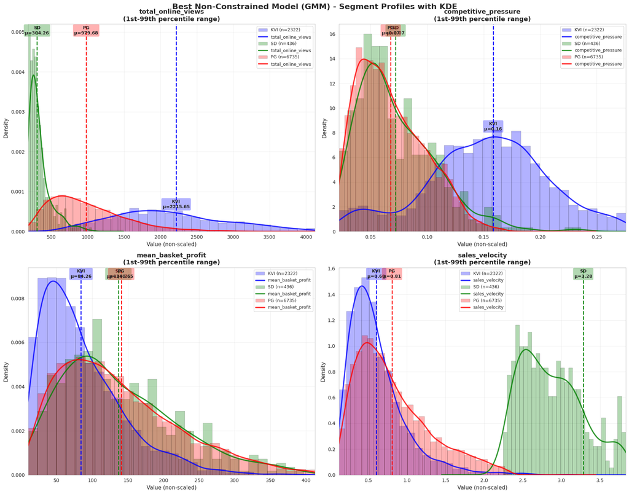

```
================================================================================
MEAN VALUES BY SEGMENT (GMM)
================================================================================

                            KVI        SD        PG
total_online_views    2215.6499  304.2592  979.6836
competitive_pressure     0.1584    0.0722    0.0679
mean_basket_profit      84.2625  136.7527  140.6516
sales_velocity           0.6036    3.2823    0.8073
```

```python
print("\n" + "="*80)
print("NON-CONSTRAINED CLUSTERING COMPARISON")
print("="*80 + "\n")

comparison_results = pd.DataFrame({
    'Model': ['K-Means', 'GMM', 'Hierarchical'],
    'Test Accuracy': [
        best_kmeans['test_accuracy'],
        best_gmm['test_accuracy'],
        best_hierarchical['test_accuracy']
    ],
    'Train Silhouette': [
        best_kmeans['train_silhouette'],
        best_gmm['train_silhouette'],
        best_hierarchical['train_silhouette']
    ],
    'Train DB Index': [
        best_kmeans['train_db'],
        best_gmm['train_db'],
        best_hierarchical['train_db']
    ],
    'Test ARI': [
        best_kmeans['test_ari'],
        best_gmm['test_ari'],
        best_hierarchical['test_ari']
    ]
})

print(comparison_results.sort_values('Train DB Index', ascending=False).to_string(index=False))

# Select overall best non-constrained model
best_overall_idx = comparison_results['Train DB Index'].idxmin()
best_overall_name = comparison_results.loc[best_overall_idx, 'Model']

if best_overall_name == 'K-Means':
    best_non_constrained = best_kmeans
elif best_overall_name == 'GMM':
    best_non_constrained = best_gmm
else:
    best_non_constrained = best_hierarchical

print(f"\n{'='*60}")
print("BEST OVERALL NON-CONSTRAINED MODEL")
print('='*60)
print(f"Model: {best_overall_name}")
print(f"Test Accuracy: {best_non_constrained['test_accuracy']:.4f}")
print(f"Parameters: {best_non_constrained['params']}")
print("\n" + "="*80)
print(f"BEST NON-CONSTRAINED MODEL VISUALIZATION: {best_overall_name}")
print(f"Parameters: {best_non_constrained['params']}")
print("="*80 + "\n")

# Prepare data with cluster assignments from best non-constrained model
df_train_best_nc = df_engineered.loc[train_indices].copy()
df_train_best_nc['cluster'] = best_non_constrained['train_labels']
df_train_best_nc['segment'] = df_train_best_nc['cluster'].map(best_non_constrained['cluster_mapping'])

print("Segment distribution (training data):")
print(df_train_best_nc['segment'].value_counts().sort_index())
print("\nProportions:")
print(df_train_best_nc['segment'].value_counts(normalize=True).sort_index().round(4))
# Visualize segment profiles with KDE, means, and quantile limits
print("\n" + "="*80)
print("SEGMENT PROFILES - ALL 4 FEATURES (KDE + MEANS + QUANTILE LIMITS)")
print("="*80 + "\n")

fig, axes = plt.subplots(2, 2, figsize=(18, 14))
axes = axes.ravel()

features_viz = ['total_online_views', 'competitive_pressure', 'mean_basket_profit', 'sales_velocity']
colors = {'KVI': 'blue', 'SD': 'green', 'PG': 'red'}

for idx, feature in enumerate(features_viz):
    # Calculate 1st and 99th percentiles for x-axis limits
    q01 = df_train_best_nc[feature].quantile(0.01)
    q99 = df_train_best_nc[feature].quantile(0.99)

    # Plot histograms and KDE for each segment
    for segment in ['KVI', 'SD', 'PG']:
        data = df_train_best_nc[df_train_best_nc['segment'] == segment][feature]

        if len(data) > 1:
            # Filter data within quantile range for visualization
            data_filtered = data[(data >= q01) & (data <= q99)]

            # Histogram with relative frequency
            axes[idx].hist(data_filtered, alpha=0.3, label=f'{segment} (n={len(data)})',
                          bins=30, color=colors[segment], density=True,
                          edgecolor='black', linewidth=0.5)

            # KDE overlay (on filtered data)
            if len(data_filtered) > 1:
                data_filtered.plot(kind='kde', ax=axes[idx], color=colors[segment],
                                  linewidth=2.5, alpha=0.8)

            # Mean line (full data mean)
            mean_val = data.mean()
            if q01 <= mean_val <= q99:  # Only show if within range
                axes[idx].axvline(mean_val, color=colors[segment], linestyle='--',
                                linewidth=2, alpha=0.9)
                axes[idx].text(mean_val, axes[idx].get_ylim()[1]*0.95,
                              f'{segment}\nμ={mean_val:.2f}',
                              ha='center', fontsize=9, fontweight='bold',
                              bbox=dict(boxstyle='round', facecolor=colors[segment], alpha=0.3))

    # Set x-axis limits to 1st-99th percentile range
    axes[idx].set_xlim(q01, q99)

    axes[idx].set_title(f'{feature}\n(1st-99th percentile range)', fontsize=13, fontweight='bold')
    axes[idx].set_xlabel('Value (non-scaled)', fontsize=11)
    axes[idx].set_ylabel('Density', fontsize=11)
    axes[idx].legend(fontsize=9, loc='best')
    axes[idx].grid(True, alpha=0.3)

plt.tight_layout()
plt.suptitle(f'Best Non-Constrained Model ({best_overall_name}) - Segment Profiles with KDE',
             y=1.00, fontsize=16, fontweight='bold')
plt.show()

# Print mean values table
print("\n" + "="*80)
print(f"MEAN VALUES BY SEGMENT ({best_overall_name})")
print("="*80 + "\n")

mean_df_nc = pd.DataFrame()
for segment in ['KVI', 'SD', 'PG']:
    segment_data = df_train_best_nc[df_train_best_nc['segment'] == segment][features_viz]
    mean_df_nc[segment] = segment_data.mean()

print(mean_df_nc.round(4))
```

### 3.3 Modelling discusion and findings

The hyperoptimized clustering model (GMM picked as the best performed) improves the misclassification, keeping the economic rationale and expected cluster properties. All the three estimated models should be used in a final ensamble model, providing complex and robust product group prediction.

## 4 Model selection - prior products distribution

**Objective:** Create ensamble model. Develop redistribution pipeline, where the ensembled model predictions are adjusted by the given product distribution expectation (10% KVI, 30% SD and 60% PD).

### 4.1 Ensamble framework

**Rationale**

Decision tree (supervised baseline):

- Learns explicit rules from 54 labeled samples.
- Captures known KVI/SD/PG decision boundaries based on ground truth.
- Interpretable feature splits validate business logic (e.g., "if profit_margin_proxy > 2.5 and price_elasticity < -1.0 → PG").
- Weakness: Overfits small labeled set, the labeled data may not be representative of the whole sample

Constrained clustering (distribution-aware):

Hyperparameter-optimized clustering (data-driven segmentation):

- Grid search silhouette score, Davies-Bouldin index on scaled features.
- Finds natural data partitions without assumptions.
- Weakness: No guarantee clusters correspond to business definitions.

```python
print("\n" + "="*80)
print("ADVANCED ENSEMBLE: VOTING + DISTRIBUTION CONSTRAINTS")
print("="*80 + "\n")

# Get predictions from all three models on training data
print("Gathering predictions from all models on unlabeled training data...\n")

# Model 1: Decision Tree predictions + probabilities
dt_train_predictions = dt.predict(X_train_cluster)
dt_train_probabilities = dt.predict_proba(X_train_cluster)

# Get class order from decision tree
dt_classes = dt.classes_

# Model 2: Monotonic Clustering
monotonic_train_predictions = df_train_monotonic_eval['pseudo_label'].values

# Model 3: Best Non-Constrained Clustering
non_constrained_train_clusters = best_non_constrained['train_labels']
non_constrained_train_predictions = pd.Series(non_constrained_train_clusters).map(
    best_non_constrained['cluster_mapping']
).values

# Combine all predictions
ensemble_train_advanced = pd.DataFrame({
    'product_id': df_engineered.loc[train_indices, 'product_id'].values,
    'dt_pred': dt_train_predictions,
    'monotonic_pred': monotonic_train_predictions,
    'non_constrained_pred': non_constrained_train_predictions
})

# Add DT probabilities
for idx, segment in enumerate(dt_classes):
    ensemble_train_advanced[f'dt_prob_{segment}'] = dt_train_probabilities[:, idx]


ensemble_train_advanced['initial_prediction'] = ensemble_train_advanced[['dt_pred','monotonic_pred','non_constrained_pred']].mode(axis=1)[0]
predicted_labels = ensemble_train_advanced['initial_prediction'].values
print("Sample of combined predictions:")
print(ensemble_train_advanced.head(10))
```

```
================================================================================
ADVANCED ENSEMBLE: VOTING + DISTRIBUTION CONSTRAINTS
================================================================================

Gathering predictions from all models on unlabeled training data...

Sample of combined predictions:
   product_id dt_pred monotonic_pred non_constrained_pred  dt_prob_KVI  \
0           1      PG             SD                   PG          0.0
1           2      SD            KVI                  KVI          0.0
2           3      PG             PG                   PG          0.0
3           4      PG             PG                   PG          0.0
4           5      PG             PG                   PG          0.0
5           6     KVI            KVI                  KVI          0.5
6           7      PG            KVI                  KVI          0.0
7           8      PG             PG                   PG          0.0
8           9      PG             PG                   PG          0.0
9          10      PG            KVI                   PG          0.0

   dt_prob_PG  dt_prob_SD initial_prediction
0         1.0         0.0                 PG
1         0.0         1.0                KVI
2         1.0         0.0                 PG
3         1.0         0.0                 PG
4         1.0         0.0                 PG
5         0.0         0.5                KVI
6         1.0         0.0                KVI
7         1.0         0.0                 PG
8         1.0         0.0                 PG
9         1.0         0.0                 PG
```

```python
print("\n" + "="*80)
print("APPLYING DISTRIBUTION CONSTRAINTS WITH CLUSTER DISTANCES")
print("="*80 + "\n")

# Ensure initial predictions exist
if 'initial_prediction' not in ensemble_train_advanced.columns:
    print("Creating initial predictions using weighted voting...\n")

    def weighted_vote(row):
        segment_scores = {'KVI': 0, 'SD': 0, 'PG': 0}
        for pred_col, weight in weights_models.items():
            segment_scores[row[pred_col]] += weight
        return max(segment_scores, key=segment_scores.get)

    ensemble_train_advanced['initial_prediction'] = ensemble_train_advanced.apply(weighted_vote, axis=1)

    print("Initial prediction distribution:")
    print(ensemble_train_advanced['initial_prediction'].value_counts().sort_index())
    print()

# Enhanced distribution adjustment function using cluster distances
def adjust_predictions_with_cluster_distances(df, clustering_model, X_scaled, target_distribution,
                                               cluster_mapping, initial_pred_col='initial_prediction',
                                               model_type='gmm'):
    """
    Adjust predictions to match target distribution using cluster distances
    for intelligent reallocation.
    """

    n_samples = len(df)
    target_counts = {seg: int(n_samples * prop) for seg, prop in target_distribution.items()}

    # Adjust for rounding
    diff = n_samples - sum(target_counts.values())
    if diff != 0:
        max_seg = max(target_distribution, key=target_distribution.get)
        target_counts[max_seg] += diff

    print(f"Target distribution ({n_samples} samples):")
    for seg in ['KVI', 'SD', 'PG']:
        count = target_counts[seg]
        print(f"  {seg}: {count:5d} ({count/n_samples*100:5.1f}%)")
    print()

    # Current distribution
    current_counts = df[initial_pred_col].value_counts().to_dict()
    for seg in ['KVI', 'SD', 'PG']:
        if seg not in current_counts:
            current_counts[seg] = 0

    print("Current distribution:")
    for seg in ['KVI', 'SD', 'PG']:
        count = current_counts[seg]
        print(f"  {seg}: {count:5d} ({count/n_samples*100:5.1f}%)")
    print()

    # Get cluster centers and labels based on model type
    if model_type == 'kmeans':
        cluster_centers = clustering_model.cluster_centers_
        cluster_labels = clustering_model.predict(X_scaled)
    elif model_type == 'gmm':
        cluster_centers = clustering_model.means_
        cluster_labels = clustering_model.predict(X_scaled)
    else:  # hierarchical
        # For hierarchical, calculate centroids from assignments
        from sklearn.neighbors import KNeighborsClassifier
        knn_temp = KNeighborsClassifier(n_neighbors=5)
        knn_temp.fit(X_scaled, clustering_model.labels_)
        cluster_labels = knn_temp.predict(X_scaled)
        cluster_centers = np.array([X_scaled[clustering_model.labels_ == i].mean(axis=0)
                                    for i in range(3)])

    # Create reverse mapping: segment -> cluster_id
    reverse_mapping = {v: k for k, v in cluster_mapping.items()}

    # Calculate distances from each point to all cluster centers
    df_work = df.reset_index(drop=True).copy()
    df_work['cluster_label'] = cluster_labels

    for seg in ['KVI', 'SD', 'PG']:
        cluster_id = reverse_mapping[seg]
        center = cluster_centers[cluster_id]
        # Euclidean distance to cluster center
        distances = np.linalg.norm(X_scaled - center, axis=1)
        df_work[f'dist_to_{seg}'] = distances

    # Calculate surplus and deficit
    surplus = {}
    deficit = {}
    for seg in ['KVI', 'SD', 'PG']:
        diff = current_counts[seg] - target_counts[seg]
        if diff > 0:
            surplus[seg] = diff
        elif diff < 0:
            deficit[seg] = -diff

    print("Adjustments needed:")
    if surplus:
        print("  Surplus (need to remove):")
        for seg, count in surplus.items():
            print(f"    {seg}: {count}")
    if deficit:
        print("  Deficit (need to add):")
        for seg, count in deficit.items():
            print(f"    {seg}: {count}")
    print()

    # Initialize adjusted predictions
    adjusted_predictions = df_work[initial_pred_col].copy()
    reallocation_log = []

    # Reallocate from surplus to deficit segments
    for surplus_seg, surplus_count in surplus.items():
        surplus_mask = (adjusted_predictions == surplus_seg)
        surplus_indices = df_work[surplus_mask].index

        if len(surplus_indices) == 0:
            continue

        candidates = df_work.loc[surplus_indices].copy()

        # Calculate reallocation score: weighted distance to deficit segments
        # Lower distance = higher score (more suitable for reallocation)
        candidates['reallocation_score'] = 0
        for deficit_seg in deficit.keys():
            # Use inverse distance as score (closer = higher score)
            candidates['reallocation_score'] += (1.0 / (candidates[f'dist_to_{deficit_seg}'] + 0.01))

        # Also consider distance from current cluster (further = easier to reallocate)
        candidates['reallocation_score'] += candidates[f'dist_to_{surplus_seg}'] * 0.5

        # Sort by reallocation score (higher = better candidate for reallocation)
        candidates = candidates.sort_values('reallocation_score', ascending=False)

        n_to_reallocate = min(surplus_count, sum(deficit.values()))

        for idx in candidates.index[:n_to_reallocate]:
            # Find best deficit segment (closest cluster)
            best_deficit_seg = None
            best_distance = float('inf')

            for deficit_seg in list(deficit.keys()):
                if deficit[deficit_seg] > 0:
                    dist = df_work.loc[idx, f'dist_to_{deficit_seg}']
                    if dist < best_distance:
                        best_distance = dist
                        best_deficit_seg = deficit_seg

            if best_deficit_seg:
                old_seg = adjusted_predictions.iloc[idx]
                adjusted_predictions.iloc[idx] = best_deficit_seg
                deficit[best_deficit_seg] -= 1

                reallocation_log.append({
                    'product_id': df_work.loc[idx, 'product_id'],
                    'from': old_seg,
                    'to': best_deficit_seg,
                    'distance_to_new': best_distance,
                    'distance_to_old': df_work.loc[idx, f'dist_to_{old_seg}'],
                    'distance_ratio': best_distance / (df_work.loc[idx, f'dist_to_{old_seg}'] + 1e-10),
                    'initial_pred': df_work.loc[idx, initial_pred_col]
                })

                if deficit[best_deficit_seg] == 0:
                    del deficit[best_deficit_seg]

    # Verify final distribution
    final_counts = adjusted_predictions.value_counts().to_dict()
    print("Final distribution after adjustment:")
    for seg in ['KVI', 'SD', 'PG']:
        count = final_counts.get(seg, 0)
        target = target_counts[seg]
        match = "✓" if count == target else "✗"
        print(f"  {match} {seg}: {count:5d} (target: {target:5d})")
    print()

    # Statistics on reallocated samples
    if reallocation_log:
        realloc_df = pd.DataFrame(reallocation_log)
        print("Reallocation statistics:")
        print(f"  Mean distance to new cluster: {realloc_df['distance_to_new'].mean():.4f}")
        print(f"  Mean distance to old cluster: {realloc_df['distance_to_old'].mean():.4f}")
        print(f"  Mean distance ratio (new/old): {realloc_df['distance_ratio'].mean():.4f}")
        print(f"  Median distance ratio: {realloc_df['distance_ratio'].median():.4f}")

    reallocation_info = {
        'n_reallocated': len(reallocation_log),
        'reallocation_log': reallocation_log
    }

    print(f"\nTotal samples reallocated: {len(reallocation_log)}")

    return adjusted_predictions, reallocation_info


# Determine model type from best_overall_name
if best_overall_name == 'K-Means':
    model_type = 'kmeans'
elif best_overall_name == 'GMM':
    model_type = 'gmm'
else:
    model_type = 'hierarchical'

print(f"Using best model: {best_overall_name} ({model_type})")
print(f"Cluster mapping: {best_non_constrained['cluster_mapping']}")
print()

# Define target distribution
target_distribution = {
    'KVI': 0.10,
    'SD': 0.30,
    'PG': 0.60
}

print("Target distribution specification:")
for seg, prop in target_distribution.items():
    print(f"  {seg}: {prop*100:.0f}%")
print()

# Apply distribution constraint with cluster distances
adjusted_predictions, reallocation_info = adjust_predictions_with_cluster_distances(
    df=ensemble_train_advanced,
    clustering_model=best_non_constrained['model'],
    X_scaled=X_train_dt,  # The 4 features used in clustering
    target_distribution=target_distribution,
    cluster_mapping=best_non_constrained['cluster_mapping'],
    initial_pred_col='initial_prediction',
    model_type=model_type
)

ensemble_train_advanced['final_prediction'] = adjusted_predictions
```

```
================================================================================
APPLYING DISTRIBUTION CONSTRAINTS WITH CLUSTER DISTANCES
================================================================================

Using best model: GMM (gmm)
Cluster mapping: {0: 'KVI', 2: 'SD', 1: 'PG'}

Target distribution specification:
  KVI: 10%
  SD: 30%
  PG: 60%

Target distribution (9493 samples):
  KVI:   949 ( 10.0%)
  SD:  2847 ( 30.0%)
  PG:  5697 ( 60.0%)

Current distribution:
  KVI:  2858 ( 30.1%)
  SD:   476 (  5.0%)
  PG:  6159 ( 64.9%)

Adjustments needed:
  Surplus (need to remove):
    KVI: 1909
    PG: 462
  Deficit (need to add):
    SD: 2371

Final distribution after adjustment:
  ✓ KVI:   949 (target:   949)
  ✓ SD:  2847 (target:  2847)
  ✓ PG:  5697 (target:  5697)

Reallocation statistics:
  Mean distance to new cluster: 4.4918
  Mean distance to old cluster: 1.7671
  Mean distance ratio (new/old): 2.9054
  Median distance ratio: 3.0020

Total samples reallocated: 2371
```

```python
# Analyze reallocation details
print("\n" + "="*80)
print("REALLOCATION ANALYSIS")
print("="*80 + "\n")

if reallocation_info['n_reallocated'] > 0:
    reallocation_df = pd.DataFrame(reallocation_info['reallocation_log'])

    print(f"Reallocation summary:")
    reallocation_summary = reallocation_df.groupby(['from', 'to']).size().reset_index(name='count')
    print(reallocation_summary.to_string(index=False))

    print("\nAverage distances for reallocated samples:")
    avg_dist_by_transition = reallocation_df.groupby(['from', 'to']).agg({
        'distance_to_new': 'mean',
        'distance_to_old': 'mean',
        'distance_ratio': 'mean'
    })
    print(avg_dist_by_transition.round(4))

    print("\nSample of reallocated products (first 10):")
    print(reallocation_df[['product_id', 'from', 'to', 'distance_to_new',
                           'distance_to_old', 'distance_ratio']].head(10))

#     # Save reallocation log
#     reallocation_df.to_csv('data/processed/reallocation_log_cluster_distances.csv', index=False)
#     print("\n✓ Reallocation log saved to: data/processed/reallocation_log_cluster_distances.csv")
# else:
#     print("No reallocation needed - initial distribution already matches target.")
```

```
================================================================================
REALLOCATION ANALYSIS
================================================================================

Reallocation summary:
from to  count
 KVI SD   1909
  PG SD    462

Average distances for reallocated samples:
         distance_to_new  distance_to_old  distance_ratio
from to
KVI  SD           4.8333           1.6096          3.3067
PG   SD           3.0810           2.4179          1.2471

Sample of reallocated products (first 10):
   product_id from  to  distance_to_new  distance_to_old  distance_ratio
0        9714  KVI  SD           8.2490           5.1224          1.6104
1        8495  KVI  SD           8.1238           5.0597          1.6056
2        2740  KVI  SD           3.3586           4.6337          0.7248
3        5066  KVI  SD           8.2584           4.9155          1.6801
4        1820  KVI  SD           7.8298           4.8075          1.6287
5        2300  KVI  SD           7.6323           4.3244          1.7649
6         395  KVI  SD           3.3029           3.9651          0.8330
7        4462  KVI  SD           3.3219           3.9626          0.8383
8        1948  KVI  SD           7.4474           4.2854          1.7379
9        8398  KVI  SD           7.1872           4.2669          1.6844
```

```python
# Summary statistics of four features after reallocation
print("\n" + "="*80)
print("FEATURE STATISTICS AFTER REALLOCATION")
print("="*80 + "\n")

# Merge final predictions with original data
df_train_final_stats = df_engineered.loc[train_indices].copy()
df_train_final_stats['final_prediction'] = ensemble_train_advanced['final_prediction'].values

# Four key features
features_viz = ['total_online_views', 'competitive_pressure', 'mean_basket_profit', 'sales_velocity']

print("="*80)
print("MEAN VALUES BY SEGMENT (After Reallocation)")
print("="*80 + "\n")

mean_df_final = pd.DataFrame()
for segment in ['KVI', 'SD', 'PG']:
    segment_data = df_train_final_stats[df_train_final_stats['final_prediction'] == segment][features_viz]
    mean_df_final[segment] = segment_data.mean()

print(mean_df_final.round(2))

print("\n" + "="*80)
print("DETAILED STATISTICS BY SEGMENT (After Reallocation)")
print("="*80 + "\n")

for segment in ['KVI', 'SD', 'PG']:
    segment_data = df_train_final_stats[df_train_final_stats['final_prediction'] == segment][features_viz]
    print(f"\n{segment} (n={len(segment_data)}):")
    print(segment_data.describe().loc[['mean', 'std', 'min', '25%', '50%', '75%', 'max']].round(2))
```

```
================================================================================
FEATURE STATISTICS AFTER REALLOCATION
================================================================================

================================================================================
MEAN VALUES BY SEGMENT (After Reallocation)
================================================================================

                          KVI       SD      PG
total_online_views    2075.55  1578.02  950.19
competitive_pressure     0.15     0.12    0.06
mean_basket_profit      71.62   117.42  140.48
sales_velocity           0.53     1.21    0.76

================================================================================
DETAILED STATISTICS BY SEGMENT (After Reallocation)
================================================================================


KVI (n=949):
      total_online_views  competitive_pressure  mean_basket_profit  \
mean             2075.55                  0.15               71.62
std               388.51                  0.03               36.99
min              1329.00                  0.10                2.12
25%              1781.00                  0.13               42.61
50%              2029.00                  0.15               66.80
75%              2344.00                  0.17               97.84
max              3114.00                  0.22              180.46

      sales_velocity
mean            0.53
std             0.17
min             0.16
25%             0.40
50%             0.51
75%             0.64
max             1.00

SD (n=2847):
      total_online_views  competitive_pressure  mean_basket_profit  \
```

[output cut: 20 more lines]

```
std               472.17                  0.03               79.20
min               116.00                  0.02                3.56
25%               604.00                  0.04               79.49
50%               862.00                  0.06              126.65
75%              1192.00                  0.08              190.21
max              3066.00                  0.17              395.10

      sales_velocity
mean            0.76
std             0.41
min             0.04
25%             0.44
50%             0.68
75%             1.03
max             1.92
```

```
================================================================================
SEGMENT PROFILES AFTER REALLOCATION - ALL 4 FEATURES (KDE + MEANS + QUANTILE LIMITS)
================================================================================
```

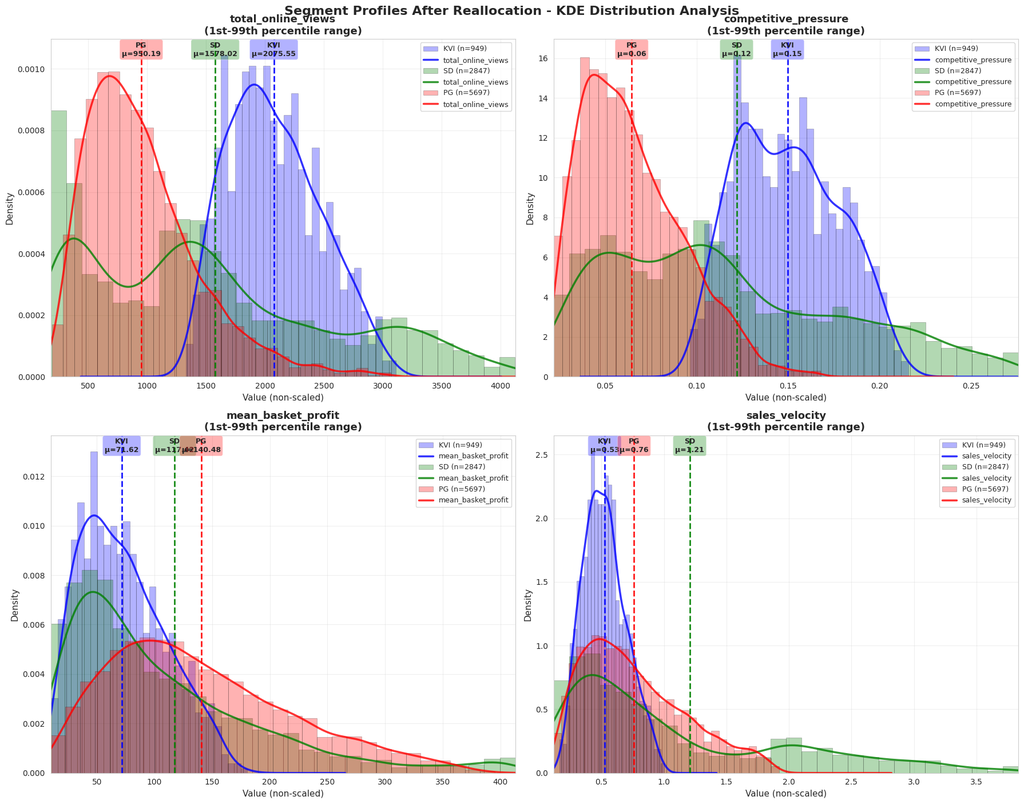

```python
import matplotlib.pyplot as plt
import pandas as pd
import numpy as np

# Visualization: Segment profiles after reallocation
print("\n" + "="*80)
print("SEGMENT PROFILES AFTER REALLOCATION - ALL 4 FEATURES (KDE + MEANS + QUANTILE LIMITS)")
print("="*80 + "\n")

fig, axes = plt.subplots(2, 2, figsize=(18, 14))
axes = axes.ravel()

features_viz = ['total_online_views', 'competitive_pressure', 'mean_basket_profit', 'sales_velocity']
colors = {'KVI': 'blue', 'SD': 'green', 'PG': 'red'}

for idx, feature in enumerate(features_viz):
    # Calculate 1st and 99th percentiles for x-axis limits
    q01 = df_train_final_stats[feature].quantile(0.01)
    q99 = df_train_final_stats[feature].quantile(0.99)

    # Plot histograms and KDE for each segment
    for segment in ['KVI', 'SD', 'PG']:
        data = df_train_final_stats[df_train_final_stats['final_prediction'] == segment][feature]

        if len(data) > 1:
            # Filter data within quantile range for visualization
            data_filtered = data[(data >= q01) & (data <= q99)]

            # Histogram with relative frequency
            axes[idx].hist(data_filtered, alpha=0.3, label=f'{segment} (n={len(data)})',
                          bins=30, color=colors[segment], density=True,
                          edgecolor='black', linewidth=0.5)

            # KDE overlay (on filtered data)
            if len(data_filtered) > 1:
                data_filtered.plot(kind='kde', ax=axes[idx], color=colors[segment],
                                  linewidth=2.5, alpha=0.8)

            # Mean line (full data mean)
            mean_val = data.mean()
            if q01 <= mean_val <= q99:  # Only show if within range
                axes[idx].axvline(mean_val, color=colors[segment], linestyle='--',
                                linewidth=2, alpha=0.9)
                axes[idx].text(mean_val, axes[idx].get_ylim()[1]*0.95,
                              f'{segment}\nμ={mean_val:.2f}',
                              ha='center', fontsize=9, fontweight='bold',
                              bbox=dict(boxstyle='round', facecolor=colors[segment], alpha=0.3))

    # Set x-axis limits to 1st-99th percentile range
    axes[idx].set_xlim(q01, q99)

    axes[idx].set_title(f'{feature}\n(1st-99th percentile range)', fontsize=13, fontweight='bold')
    axes[idx].set_xlabel('Value (non-scaled)', fontsize=11)
    axes[idx].set_ylabel('Density', fontsize=11)
    axes[idx].legend(fontsize=9, loc='best')
    axes[idx].grid(True, alpha=0.3)

plt.tight_layout()
plt.suptitle('Segment Profiles After Reallocation - KDE Distribution Analysis',
             y=1.00, fontsize=16, fontweight='bold')
plt.show()
```

### 4.2 Modelling conclusion

**Limitations and red flags**

The overall cluster separation may still not be sufficient. We can see the SD group to have significant univariate distribution portion above the KVI group for features total_online_views and competitive pressure. It shows that prior to the redistribution, major part of now SD group was classified as KVI.

**Productionization**

The whole modelling process (without the hyperoptimization) is converted into the production pipeline, where train.py and predict.py, with which the prediction.csv is created. You may find the whole pipeline in the same folder as this notebook. For more details about the production pipeline read the project attached README.txt file.